# Hopping of CBS-Sox2P constructs from LP-116kb

Mathias Eder

2026-03-02

# Revision

Scale figure 2F, G and H the same!

# Nomenclature

When generating the datasets for this hopping experiments, we named the data often with their plasmid names. Here is a short translator for the nomenclature: pME034 –> Sox2P insert pMK01 –> 3xCBS_Fw_Sox2P insert pMK02 –> 3xCBS_Rv_Sox2P insert pMK03 –> 1xCBS_Fw_Sox2P insert

# Script to generate the following figures

- fig S1B
- fig S1C
- fig S1E
- fig 2C
- fig S2B-S2E
- fig 2D
- fig S2A
- fig S2A
- fig S5G
- fig 6D
- fig S2F-S2I

# Set-up

##Libraries Load the libraries and set the parameters.

```r
# Load dependencies
library(GenomicRanges)
library(rtracklayer)
library(gtools)
library(tidyverse)
```

```r
library(dtplyr)
library(dplyr)
library(tidyr)
library(ggbeeswarm)
library(ggplot2)
#library(broom)
library(Biostrings)
library(stringr)
library(readr)
#library(tagMeppr)
#library(withr)
library(knitr)
library(RColorBrewer)
#library(tagmapAnalyseR)
# library(UpSetR)
# library(ComplexHeatmap)
library(purrr)
# library(ggpubr)
# library(cowplot)
library(RcppRoll)
library(viridis)
library(plotly)
library(GGally)
library(cowplot)
library(ggh4x)
library(ggsignif)

split_string <- function(vect,sep,N1,N2=N1){
  library(stringr)
  sapply(vect, function(X){
    paste(str_split(X,sep)[[1]][N1:N2],collapse = sep)
  },USE.NAMES = F)
}
```

## Paths & parameters

```r
setwd("/DATA/projects/CTCF_Sox2/Scripts/Revisions/Figure2_Scaling")

#datatag
datetag = paste0("ME",format(Sys.time(), '%Y%m%d'))

# Prepare output
output_dir <- paste0("analysis_",datetag)
dir.create(output_dir, showWarnings = FALSE)
```

```r
library(knitr)
opts_chunk$set(fig.width = 20, fig.height = 8, cache = T,
               message = F, warning = F,
               dev=c('png', 'pdf'),
               fig.path = file.path(output_dir, "figures/"))
pdf.options(useDingbats = FALSE)
```

# File paths

```r
path_CTCF_sites = "/DATA/usr/v.franceschini/Workspaces/2024_01_MATHIAS_CTCF_PEAKS/VF240812_calling_CTCF_motifs_again/02_OUTPUTS/CTCF_sites/6764_2_ME_E2_CGATGT_S2_R1_001_peaks_motifs.bed"

path_tib_23_ints = "/DATA/projects/CTCF_Sox2/Integrations_files/mapped_integrations_-116kb_Sox2P_pools.txt"
path_tib_CTCF_Sox2P = "/DATA/projects/CTCF_Sox2/Integrations_files/mapped_integrations_-116kb_CBS_Sox2P_pools.txt"


path_median_mTurq_relevant_cell_lines = "/DATA/projects/CTCF_Sox2/Info_files/me20250707_median_mTurq_mCherry_GFP_sorting_all.tsv"
path_sorting_stats = "/DATA/projects/CTCF_Sox2/Info_files/me20250707_stats_for_expression_score_mCherry.tsv"
```

#Load functions

```r
source("/DATA/projects/Sox2/General_functions/CM20240621_general_plotting_functions.R")
source("/DATA/projects/Sox2/General_functions/CM20250318_new_expression_score_functions.R")
```

# Relevant annotations

```r
# Location of enhancer / gene
enhancer <- GRanges(seqnames = "chr3",
                    ranges = IRanges(start = 34753415,
                                     end = 34766401),
                    strand = "*")

#gene based on mm10, ucsc browser, RefSeq annotation
# Sox2
# chr3:34649995-34652461 (+)
# id = NM_011443.4

Sox2_gene <- GRanges(seqnames = "chr3",
                    ranges = IRanges(start = 34649995,
                                     end = 34652461),
                    strand = "+")

landingPad_23 <- GRanges(seqnames = "chr3",
                    ranges = IRanges(start = 34643960,
                                     end = 34643962),
                    strand = "+")

landingPad_8 <- GRanges(seqnames = "chr3",
                    ranges = IRanges(start = 34721183,
                                     end = 34721184),
                    strand = "+")


LP_tib = tibble(landing_pad = c("LP23", "LP8"),
                start = c( start(landingPad_23),start(landingPad_8)))

# Add annotations from Brosh paper
Brosh <- import.bed('/DATA/projects/CTCF_Sox2/external_datasets/annotations_Brosh_paper/enhancer_elements_Brosh2023_Sox2_V2.bed')


#CTCF sites based on our own mapping
# new analysis (based on mapping to mm10 only)
CTCF_mm10_new <- import.bed('/DATA/usr/v.franceschini/Workspaces/2024_01_MATHIAS_CTCF_PEAKS/VF240812_calling_CTCF_motifs_again/02_OUTPUTS/CTCF_sites/6764_2_ME_E2_CGATGT_S2_R1_001_peaks_motifs.bed')

#filtering:
CTCF_mm10.chr3 <- CTCF_mm10_new[seqnames(CTCF_mm10_new)== 'chr3']
# add the missing site after the SCR
CTCF_mm10.chr3_extra = sort(c(CTCF_mm10.chr3,
                         GRanges(seqnames = "chr3",
                                 IRanges(start = 34772210, end = 34772210),
                                 strand = "+")),
                         ignore.strand = T)


prange_zoom = c(34500000 , 35000000)
prange2 = c(34000000, 35500000)
prange_far = c(32000000, 37000000)
#zoom in on only the SCR +- 50kb
prange_LP = c(start(landingPad_23)-5E4, end(landingPad_23)+5E4)
prange_SCR = c(start(enhancer)-5E4, end(enhancer)+5E4)
prange_plot = c(32643960, 36643960) #+/- 2MB from landing pad
prange_loop = c(34631804, 34778268)
prange_zoom = c(34.5E6, 35E6)
prange_zoom_paper = c(34.59E6, 34.83E6)
prange_SCR = c(34.725E6, 34.785E6)
range_2Mb = c(33.643960E6, 35.643960E6)
# Focus on peak around the SCR
prange_ChIP = c(34611804,34810000)
```

## Colour setup

```r
myCols_insert_cell_line <- c(
  `23_MK01_C5` = '#1b9e77',   # Teal green
  `23_MK02_C2` = '#d95f02',   # Strong orange
  `23_MK03_C1` = '#7570b3',   # Purple
  `23_34A` = 'black', # blue for ctrl cell line
  `8_MK01_C1` = '#1b9e77',   # Teal green
  `8_MK01_C2` = '#1b9e77',   # Teal green
  `8_MK02_C5` = '#d95f02',   # Strong orange
  `8_MK03_C3` = '#7570b3',   # Purple
  `8_34` = 'black' # blue for ctrl cell line
)

col_scale_MK_CL <- scale_colour_manual(
  name = "cell_line",
  values = myCols_insert_cell_line,
  aesthetics = c("colour", "fill")
)
```

# Load data

```r
#load the -116kb data (LP23)
tib_23_all_data = read_tsv(path_tib_23_ints) %>%
  filter(chr %in% paste0("chr", c(1:19, "X"))) %>%
  mutate(chr = factor(chr, levels = paste0("chr", c(1:19, "X"))))

#the control pool in E2285 (rep3) was sequenced as 10 separate libraries, combine them into one sample
tib_23_E2285_ctrls = tib_23_all_data %>%
  filter(replicate == "rep3" & insert == "Sox2P" & sample_type == "control pool") %>%
  mutate(sample_name = "Sox2P-reporter -116 kb, unsorted control pool rep3")%>%
  group_by(chr, start, end, seq, strand, replicate, experiment, launch_pad_location, insert, genotype, sample_type, sorted_gate, pool_nr) %>%
  summarize(read_count = sum(read_count),
            read_count_1 = sum(read_count_1),
            read_count_2 = sum(read_count_2), .groups = "keep")

tib_23 = tib_23_all_data %>%
  #select the rest of the data
  filter(!(replicate == "rep3" & insert == "Sox2P" & sample_type == "control pool")) %>%
  select(chr, start, end, seq, strand, replicate, experiment, launch_pad_location, insert, genotype, sample_type, sorted_gate, pool_nr,
         read_count, read_count_1, read_count_2)%>%
  #add merged controls back in
  bind_rows(tib_23_E2285_ctrls) %>%
  #mark hopped integrations
  mutate(hopped = start != 34643961,
         cell_line = "23_34A") %>%
 filter(!(start >= 34721183 & start <= 34721192)) #filter contamination from LP8


# Load CTCF_Sox2P data
tib_CTCF_Sox2P = read_tsv(path_tib_CTCF_Sox2P) %>%
  filter(chr %in% paste0("chr", c(1:19, "X"))) %>%
  mutate(chr = factor(chr, levels = paste0("chr", c(1:19, "X")))) %>%
  mutate(LP = case_when(experiment == "E2292" ~ "LP8",
                        .default = "LP23"),
         hopped = case_when(LP == "LP8" ~ start  < 34721183 | start > 34721192,
                            LP == "LP23" ~ start != 34643961)) %>%
  select(chr, start, end, seq, strand, replicate, experiment, launch_pad_location, insert, genotype, sample_type, sorted_gate, pool_nr,
         read_count, read_count_1, read_count_2, hopped, cell_line)


# Filter integrations
tib_filtered = bind_rows(tib_23, tib_CTCF_Sox2P) %>%
  #add variables used in the plotting (old names of cell lines etc)
  mutate(population_tmp = case_when(sample_type == "control pool" ~ "ctrl",
                                .default = sorted_gate),
         population = case_when(population_tmp == "P01" ~ "P1",
                                population_tmp == "P56" ~ "P5",
                                .default = population_tmp),
         landing_pad = case_when(launch_pad_location == "-116 kb" ~ "LP23",
                                 launch_pad_location == "-39 kb" ~ "LP8")) %>%
  #annotate confidence of mapping (one or both ITRs)
  mutate(mapped_arms = case_when(read_count_1 == 0 ~ "rv_only",
                                 read_count_2 == 0 ~ "fw_only",
                                 read_count_1 > 0 & read_count_2 > 0 ~ "both_arms")) %>%

  #filter the data
  filter(population == "ctrl" | read_count >= 2) %>% #for ctrl distribution 1 mapping read is enough
  filter(strand %in% c("+", "-")) %>%
  select(-c(population_tmp))

# quick check
table(tib_filtered$cell_line, tib_filtered$population)
```

```
##
##              ctrl   P1   P2   P3   P4   P5   P6
##   23_34A     4944  134  937  674  396  437  875
##   23_MK01_C5  986  179  214  219  207  236 1486
##   23_MK02_C2  960   24  790  280  241  245  625
##   23_MK03_C1 2203  162  357  201  162  185 1719
```

```r
table(tib_filtered$population, tib_filtered$chr)
```

```
##
##        chr1 chr2 chr3 chr4 chr5 chr6 chr7 chr8 chr9 chr10 chr11 chr12 chr13
##   ctrl  462  458 3314  352  366  378  318  429  335   322   335   264   279
##   P1      0    3  484    0    1    4    1    0    3     0     1     0     0
##   P2      5   12 2156    6    9    6   11    4   14     4    11     7    14
##   P3     14    8 1132   21   12   13   13   20   25     6    19     7     8
##   P4     12   12  803   13   15    7    9   13   23    10     9     7    14
##   P5     12   14  899   11   10   21   11   13   20    12    10     5    12
##   P6     54   55 3964   51   46   52   45   52   63    41    45    33    26
##
##        chr14 chr15 chr16 chr17 chr18 chr19 chrX
##   ctrl   279   226   232   236   196   146  166
##   P1       0     0     0     2     0     0    0
##   P2       4     5     5    13     4     6    2
##   P3      10    17    13    11     8    12    5
##   P4      11    10    12    13     4     7    2
##   P5       7     7     6    10     7     8    8
##   P6      30    36    30    35    22    14   11
```

```r
tib_filtered %>% filter(chr == "chr3") %>%
  group_by(population, cell_line) %>% tally() %>% spread(cell_line, n)
```

```
## # A tibble: 7 × 5
## # Groups:   population [7]
##   population `23_34A` `23_MK01_C5` `23_MK02_C2` `23_MK03_C1`
##   <chr>         <int>        <int>        <int>        <int>
## 1 ctrl           1603          341          578          792
## 2 P1              127          174           24          159
## 3 P2              819          208          780          349
## 4 P3              466          206          270          190
## 5 P4              216          200          230          157
## 6 P5              273          227          232          167
## 7 P6              526         1393          562         1483
```

```r
tib_filtered_P1_strict = tib_filtered %>%
  filter(!(population == "P1" & mapped_arms != "both_arms")) %>% #only keep P1 integrations with 2 mapped arms
  filter(!(population == "P0" & mapped_arms != "both_arms")) %>% #only keep P0 integrations with 2 mapped arms from LP-39kb
  mutate(population = factor(population))
```

## Remove contamination of E2401

```r
tib_E2401 = tib_filtered %>% filter(experiment == "E2401")

# Find regions of contaminated integrations
top_dupl_locations = tib_E2401 %>%
  filter(chr == "chr3" & hopped & strand != "*") %>%
  group_by(start, strand) %>%
  summarize(N_samples_found = n()) %>%
  ungroup() %>%
  slice_max(N_samples_found, n = 18)

top_dupl_locations_2 = tib_E2401 %>%
  filter(chr =="chr3" & hopped & strand != "*") %>%
  group_by(start, strand) %>%
  summarize(N_cell_lines_found = length(unique(cell_line))) %>%
  filter(N_cell_lines_found == 3)

top_combined = top_dupl_locations %>% left_join(top_dupl_locations_2, by = c("start", "strand"))
#Note:
# In this way we find 2200 integrations in the three cell lines that can be found from 149 times to 37 times.
# all of the 18 hits are found in all 3 cell lines


# Remove integrations from data
tib_E2401_curated <- tib_E2401 %>%
  filter(
    ! (start  %in% top_dupl_locations$start &
       strand %in% top_dupl_locations$strand)
  )

#filter without old E2401
tib_filtered_1 = tib_filtered %>% filter(experiment != "E2401")

tib_filtered_curated = bind_rows(tib_filtered_1, tib_E2401_curated)

tib_filtered_curated_strict = tib_filtered_curated %>%
  filter(!(population == "P1" & mapped_arms != "both_arms")) %>% #only keep P1 integrations with 2 mapped arms
  filter(!(population == "P0" & mapped_arms != "both_arms")) %>% #only keep P0 integrations with 2 mapped arms at LP-39kb
  mutate(population = factor(population))

#saveRDS(tib_filtered_curated_strict, file = "/DATA/projects/CTCF_Sox2/Scripts/for_figures/Figure_2/tib_filtered_curated_strict.rds")
```

#Expression data

```r
#load median expression values (from sorting pdfs)
median_sorted_mTurq = read_tsv(path_median_mTurq_relevant_cell_lines) %>%
  select(experiment, cell_line, mCh_status, population, replicate, construct, mCherry_selection, mTurq, mCherry, GFP)

#get a general mTurq level per gate, for the mCh+ hopping
general_mTurq_mChpos = median_sorted_mTurq %>%
  filter(str_detect(population, "^P\\d+")) %>%
  filter(mCherry_selection == "mCh+") %>%
  group_by(cell_line, population, construct, mCherry_selection) %>%
  summarise(mTurq_mean = mean(mTurq),
            mCherry_mean = mean(mCherry),
            GFP_mean = mean(GFP)) %>%
  ungroup() %>%
  select(cell_line, population, mTurq_mean, mCherry_mean, GFP_mean)

#add mTurq values to the integration tibble
tib_filtered_FACS_vals = left_join(tib_filtered_curated_strict, general_mTurq_mChpos, by = join_by(cell_line, population)) %>%
  filter(population != "ctrl") %>%
   dplyr::rename(mTurq_expr_gate = mTurq_mean,
                 mCh_expr_gate = mCherry_mean)

#check that all integrations have a fluorescence value:
tib_filtered_FACS_vals %>% filter(is.na(mTurq_expr_gate))
```

```
## # A tibble: 0 × 24
## # ℹ 24 variables: chr <fct>, start <dbl>, end <dbl>, seq <chr>, strand <chr>,
## #   replicate <chr>, experiment <chr>, launch_pad_location <chr>, insert <chr>,
## #   genotype <chr>, sample_type <chr>, sorted_gate <chr>, pool_nr <dbl>,
## #   read_count <dbl>, read_count_1 <dbl>, read_count_2 <dbl>, hopped <lgl>,
## #   cell_line <chr>, population <chr>, landing_pad <chr>, mapped_arms <chr>,
## #   mTurq_expr_gate <dbl>, mCh_expr_gate <dbl>, GFP_mean <dbl>
```

#Sorting statistics

```r
sorting_stats_tib_raw = read_tsv(path_sorting_stats)

sorting_stats_tib = sorting_stats_tib_raw %>%
  mutate(recorded_fraction = (recorded_count + 1)/total_recorded) %>% #recorded fraction with psuedocount of 1
  mutate(weigh_factor = recorded_fraction / sorted_count,
         weigh_factor_1M = weigh_factor * 1E6) # weigh factor 1M is just to make the factor more easily human readable
```

```r
# number or replications per population
sorting_stats_tib_repN = sorting_stats_tib %>%
  filter(cell_line %in% c("23_34A", "23_MK01_C5", "23_MK02_C2", "23_MK03_C1")) %>%
  group_by(cell_line, population) %>%
  summarize(N_reps = n()) %>% #number of reps per population per cell line
  group_by(cell_line) %>%
  mutate(min_reps_CL = min(N_reps) ) %>% #least replicated population
  mutate(rep_weigh_factor = min_reps_CL/N_reps) #scale the other populations to the least replicated pop

# adjust weigh factor by the replicate weigh factor
sorting_stats_tib_repcor =
  sorting_stats_tib %>%
  left_join(sorting_stats_tib_repN) %>%
  mutate(weigh_factor_old = weigh_factor,
         weigh_factor = weigh_factor_old * rep_weigh_factor)
```

```r
tib_filtered_FACS_vals %>%
  filter(cell_line %in% c("23_34A", "23_MK01_C5", "23_MK02_C2", "23_MK03_C1")) %>%
  group_by(cell_line, experiment, replicate, population) %>%
  filter(hopped) %>%
  summarize(N_ints = n()) %>%
  left_join(sorting_stats_tib)
```

```
## # A tibble: 56 × 11
## # Groups:   cell_line, experiment, replicate [10]
##    cell_line experiment replicate population N_ints recorded_count
##    <chr>     <chr>      <chr>     <chr>       <int>          <dbl>
##  1 23_34A    E2138      rep1      P1             20              9
##  2 23_34A    E2138      rep1      P2            329            152
##  3 23_34A    E2138      rep1      P3             55           3278
##  4 23_34A    E2138      rep1      P4             43          25577
##  5 23_34A    E2138      rep1      P5             28          53113
##  6 23_34A    E2138      rep1      P6            244          13239
##  7 23_34A    E2282      rep2      P1             20              9
##  8 23_34A    E2282      rep2      P2            241            865
##  9 23_34A    E2282      rep2      P3             80           9539
## 10 23_34A    E2282      rep2      P4             56          32466
## # ℹ 46 more rows
## # ℹ 5 more variables: total_recorded <dbl>, sorted_count <dbl>,
## #   recorded_fraction <dbl>, weigh_factor <dbl>, weigh_factor_1M <dbl>
```

#Functions

```r
# Plotting ranges
prange_zoom = c(34.5E6, 35E6)
prange_zoom_paper = c(34.59E6, 34.83E6)
prange_SCR = c(34.725E6, 34.785E6)


# Color annotations
## SCR
brown = "#ffb000"

#color schemes
myCols_blue = c('#525252', "#080E5B",  "#212B71", "#3A4987", "#465893", "#5A719A", "#6C8AA0")
names(myCols_blue) = c("ctrl", paste0("P", 1:6))
colScale7_blue <- scale_colour_manual(name = "population", values = myCols_blue)
fillScale7_blue <- scale_fill_manual(name = "population", values = myCols_blue)

myCols_blue_strand = c( "#080E5B", "#5A719A")
names(myCols_blue_strand) = c("+","-")
colScale2_blue <- scale_colour_manual(name = "strand", values = myCols_blue_strand)
fillScale2_blue <- scale_fill_manual(name = "strand", values = myCols_blue_strand)
```

#Create color palette for different cell lines

```r
myCols_green = c('#525252',"#0A3F30", "#175643", "#246D58", "#30846B", "#3D9B7E", "#49B292")
names(myCols_green) = c("ctrl", paste0("P", 1:6))
colScale7_green <- scale_colour_manual(name = "population", values = myCols_green)
fillScale7_green <- scale_fill_manual(name = "population", values = myCols_green)

myCols_orange = c('#525252', "#572601", "#72380B", "#8F4A15", "#AA5C20", "#C66D2A", "#E07F34")
names(myCols_orange) = c("ctrl", paste0("P", 1:6))
colScale7_orange <- scale_colour_manual(name = "population", values = myCols_orange)
fillScale7_orange <- scale_fill_manual(name = "population", values = myCols_orange)

myCols_purple = c('#525252', "#2E2D47", "#424060", "#565378", "#696791", "#7D7AA9", "#918DC2")
names(myCols_purple) = c("ctrl", paste0("P", 1:6))
colScale7_purple <- scale_colour_manual(name = "population", values = myCols_purple)
fillScale7_purple <- scale_fill_manual(name = "population", values = myCols_purple)
```

```r
all_exp = unique(tib_filtered_curated_strict$experiment)
```

## Plotting Beeswarm function

```r
plot_beeswarm_only = function(TIB, CL = "23_34A", EXP = all_exp, P_RANGE = prange_zoom,
                              PLOT_CTCF = F, PLOT_ANNOT = T,
                              TITLE = NULL, POINT_SIZE = 0.75, RANDOM_METHOD = "quasirandom",
                              NEXT_RANGE = NULL){
  tib_for_plot = filter(TIB, hopped & chr == "chr3" & cell_line %in% CL & experiment %in% EXP & start >= P_RANGE[1] & start <= P_RANGE[2])
  LP_tib_cl = select(tib_for_plot, c(cell_line, landing_pad)) %>%
    distinct() %>% left_join(LP_tib)

  ggplot(filter(tib_for_plot, hopped & chr == "chr3" & cell_line %in% CL & experiment %in% EXP),
         aes(x = start, y = population, col = population)) +
    {if(length(CL)>1) facet_grid(cell_line ~ .)} +  #only facet when necessary

    {if (PLOT_ANNOT)
      list( #add elements in a list, you cannot use + inside an if statement
        # annotate enhancer
        geom_vline(xintercept = c(start(enhancer), end(enhancer)), col = brown),
        annotate("rect", xmin = start(enhancer), xmax = end(enhancer), ymin = -Inf, ymax = Inf, alpha = .2, fill = brown),
        # annotate gene
        annotate("rect", xmin = start(Sox2_gene), xmax = end(Sox2_gene), ymin = -Inf, ymax = Inf, alpha = .2, fill = 'red'),
        geom_vline(xintercept = c(start(Sox2_gene), end(Sox2_gene)), col = 'red') )} +

     #annotate landing pad
    {if(PLOT_ANNOT & length(CL)== 1)
      geom_vline(xintercept = pull(
        filter(LP_tib, landing_pad %in% unique(tib_for_plot$landing_pad)),
        start),
        col = 'darkgrey')} +
    {if(PLOT_ANNOT & length(CL) > 1)
       geom_vline(data = LP_tib_cl, aes(xintercept = start), col = 'darkgrey')} +

    # # annotate CTCFs
    {if(PLOT_CTCF)geom_vline(xintercept = start(CTCF_mm10.chr3_extra), col = 'darkgrey', lty="11")}+
    {if(!is.null(NEXT_RANGE)) geom_rug(data = tibble(range = NEXT_RANGE),
                                       aes(x = range),
                                       fill = 'grey',
                                       inherit.aes = F)}+


    #datapoints
    geom_quasirandom(alpha = 0.5, size = POINT_SIZE, varwidth = T, bandwidth = 0.8,
                     # shape = 16, #changes to point without border, so alpha applies to the whole point
                     method = RANDOM_METHOD,
                     stroke = NA) +
    geom_text(data = plyr::count(tib_for_plot, vars = c("cell_line", "population")), aes(label = paste("n = ", freq, sep = ""),
                                                                                         x = Inf),
              hjust = "inward", vjust = "top",
              col = 'black') +

    #layout:
    labs(x='Genomic coordinate (Mb)',y='sorted gate') +
    theme_classic(base_size = 16) +
    theme(legend.position = "none") +
    scale_x_continuous(breaks = scales::pretty_breaks(n = 6), labels = scales::unit_format(scale = 1E-6, accuracy = 0.01, unit=NULL),
                       limits=P_RANGE, expand=c(0,0)) +
    scale_y_discrete(limits = rev, drop=F) +
    ggtitle(TITLE) +
    ## CHANGED: choose the appropriate colour scale based on CL
    { if (length(CL)==1) {
        switch(CL,
          "23_34A"       = colScale7_blue,
          "23_MK01_C5"   = colScale7_green,
          "23_MK02_C2"   = colScale7_orange,
          "23_MK03_C1"   = colScale7_purple,
          colScale7_blue  # default fallback
        )
      } else {
        colScale7_blue  # when faceting multiple lines, fall back to blue (or choose your own default)
      }
    }
}
```

## Figure 2C, S2A - Scatterplot of integrations

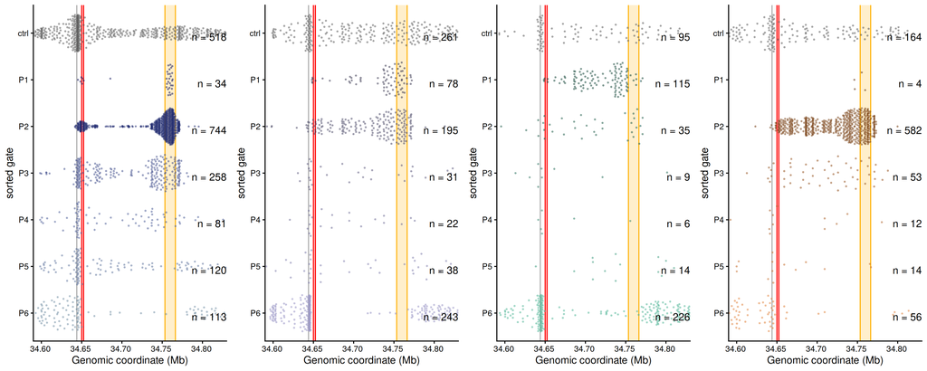

```r
# Plot Sox2P
pSox2P_bs =
plot_beeswarm_only(TIB = tib_filtered_curated_strict %>%
                   filter(hopped & chr == "chr3" & population != "P0") %>% droplevels(),
                   EXP = all_exp,
                   CL = "23_34A",
                   PLOT_ANNOT = T,
                   PLOT_CTCF = F,
                   P_RANGE = prange_zoom_paper,
                   POINT_SIZE = 1.5)

# Plot 1xCBS_Fw_Sox2P
p1xCBS_Fw_Sox2P_bs =
plot_beeswarm_only(TIB = tib_filtered_curated_strict %>%
                   filter(hopped & chr == "chr3" & population != "P0") %>% droplevels(),
                   EXP = all_exp,
                   CL = "23_MK03_C1",
                   PLOT_ANNOT = T,
                   PLOT_CTCF = F,
                   P_RANGE = prange_zoom_paper,
                   POINT_SIZE = 1.5)


# Plot 3xCBS_Fw_Sox2P
p3xCBS_Fw_Sox2P_bs =
plot_beeswarm_only(TIB = tib_filtered_curated_strict %>%
                   filter(hopped & chr == "chr3" & population != "P0") %>% droplevels(),
                   EXP = all_exp,
                   CL = "23_MK01_C5",
                   PLOT_ANNOT = T,
                   PLOT_CTCF = F,
                   P_RANGE = prange_zoom_paper,
                   POINT_SIZE = 1.5)

# Plot 3xCBS_Rv_Sox2P
p3xCBS_Rv_Sox2P_bs =
plot_beeswarm_only(TIB = tib_filtered_curated_strict %>%
                   filter(hopped & chr == "chr3" & population != "P0") %>% droplevels(),
                   EXP = all_exp,
                   CL = "23_MK02_C2",
                   PLOT_ANNOT = T,
                   PLOT_CTCF = F,
                   P_RANGE = prange_zoom_paper,
                   POINT_SIZE = 1.5)

# Plot 1xCBS_Fw_Sox2P
p1xCBS_Fw_Sox2P_bs =
plot_beeswarm_only(TIB = tib_filtered_curated_strict %>%
                   filter(hopped & chr == "chr3" & population != "P0") %>% droplevels(),
                   EXP = all_exp,
                   CL = "23_MK03_C1",
                   PLOT_ANNOT = T,
                   PLOT_CTCF = F,
                   P_RANGE = prange_zoom_paper,
                   POINT_SIZE = 1.5)

plot_grid(pSox2P_bs, p1xCBS_Fw_Sox2P_bs, p3xCBS_Fw_Sox2P_bs, p3xCBS_Rv_Sox2P_bs, align = "hv", nrow = 1)
```

# Strand based beeswarm function

```r
plot_beeswarm_only_stranded = function(TIB, CL = "23_34A", EXP = all_exp, P_RANGE = prange_zoom,
                              PLOT_CTCF = FALSE, PLOT_ANNOT = TRUE,
                              SPLIT_STRAND = FALSE,
                              TITLE = NULL, POINT_SIZE = 0.75, RANDOM_METHOD = "quasirandom",
                              NEXT_RANGE = NULL){

  # 1) subset once
  tib_for_plot <- TIB %>%
    filter(hopped, chr == "chr3",
           cell_line %in% CL, experiment %in% EXP,
           between(start, P_RANGE[1], P_RANGE[2]))

  # 2) landing‐pad join (unchanged)
  LP_tib_cl <- tib_for_plot %>%
    distinct(cell_line, landing_pad) %>%
    left_join(LP_tib, by = "landing_pad")

  # 3) compute counts *with* strand if requested
  if (SPLIT_STRAND) {
    count_df <- tib_for_plot %>%
      count(cell_line, strand, population)
  } else {
    count_df <- tib_for_plot %>%
      count(cell_line, population)
  }


  # 4) now build the plot
  ggplot(tib_for_plot,
         aes(x = start, y = population, col = population)) +

    # faceting
    {
      if (SPLIT_STRAND) {
        if (length(CL) > 1) facet_grid(cell_line ~ strand)
        else                facet_wrap(~ strand)
      } else {
        if (length(CL) > 1) facet_grid(cell_line ~ .)
        else                NULL
      }
    } +

    # (all your annotations go here, unchanged) … +
    {if (PLOT_ANNOT)
      list( #add elements in a list, you cannot use + inside an if statement
        # annotate enhancer
        geom_vline(xintercept = c(start(enhancer), end(enhancer)), col = brown),
        annotate("rect", xmin = start(enhancer), xmax = end(enhancer), ymin = -Inf, ymax = Inf, alpha = .2, fill = brown),
        # annotate LP
        geom_vline(xintercept = start(landingPad_8), col = "black", linetype = "dotted"),
        geom_vline(xintercept = start(landingPad_23), col = "black", linetype = "dotted"),

        # annotate gene
        annotate("rect", xmin = start(Sox2_gene), xmax = end(Sox2_gene), ymin = -Inf, ymax = Inf, alpha = .2, fill = 'red'),
        geom_vline(xintercept = c(start(Sox2_gene), end(Sox2_gene)), col = 'red') )} +

    # # annotate CTCFs
    {if(PLOT_CTCF)geom_vline(xintercept = start(CTCF_mm10.chr3_extra), col = 'darkgrey', lty="11")}+
    {if(!is.null(NEXT_RANGE)) geom_rug(data = tibble(range = NEXT_RANGE),
                                       aes(x = range),
                                       fill = 'grey',
                                       inherit.aes = F)}+

    geom_quasirandom(alpha = 0.5, size = POINT_SIZE, varwidth = TRUE,
                     bandwidth = 0.8, method = RANDOM_METHOD, stroke = NA) +

    # 5) the *only* geom_text, pointing at count_df
    geom_text(
      data = count_df,
      aes(label = paste0("n = ", n), x = Inf),
      hjust = "inward", vjust = "top",
      col = 'black'
    ) +

    # 6) scales / theme / title (unchanged) …
    labs(x = 'Genomic coordinate (Mb)', y = 'sorted gate') +
    theme_classic(base_size = 16) +
    theme(legend.position = "none") +
    scale_x_continuous(breaks = scales::pretty_breaks(n = 6), labels = scales::unit_format(scale = 1E-6, accuracy = 0.01, unit=NULL),
                       limits=P_RANGE, expand=c(0,0)) +
    scale_y_discrete(limits = rev, drop=F) +
    ggtitle(TITLE) +
    ## CHANGED: choose the appropriate colour scale based on CL
    { if (length(CL)==1) {
        switch(CL,
          "23_34A"       = colScale7_blue,
          "23_MK01_C5"   = colScale7_green,
          "23_MK02_C2"   = colScale7_orange,
          "23_MK03_C1"   = colScale7_purple,
          colScale7_blue  # default fallback
        )
      } else {
        colScale7_blue  # when faceting multiple lines, fall back to blue (or choose your own default)
      }
    }

}
```

## Plot Beeswarm of stranded integrations Fig. S2B-S2E

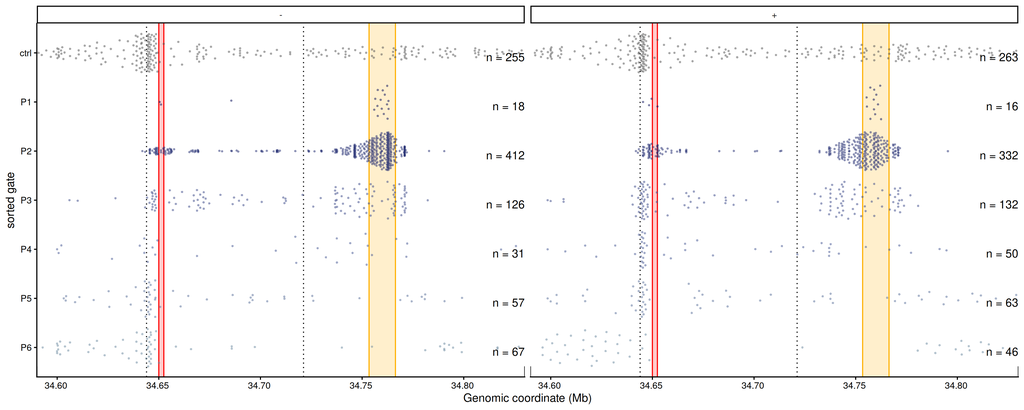

```r
# Plot Sox2P stranded
pBS_Sox2P_stranded =
plot_beeswarm_only_stranded(TIB = tib_filtered_curated_strict %>%
                              filter(hopped & chr == "chr3" & experiment %in% all_exp) %>%
                              droplevels(),
                   CL = c("23_34A"),
                   SPLIT_STRAND = T,
                   PLOT_ANNOT = T,
                   PLOT_CTCF = F,
                   P_RANGE = prange_zoom_paper,
                   POINT_SIZE = 1.5,
                   NEXT_RANGE = prange_zoom_paper
)
pBS_Sox2P_stranded
```

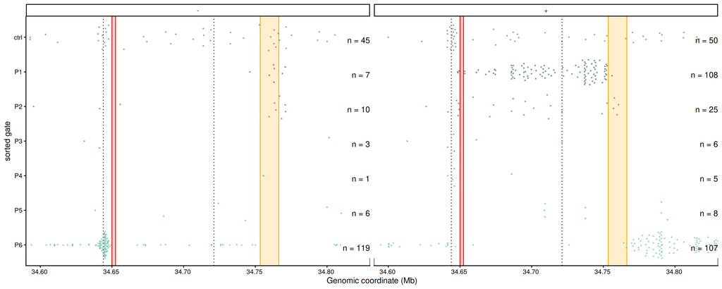

```r
# Plot 3xCBS_Fw_Sox2P stranded
pBS_3xCBS_Fw_Sox2P_stranded =
plot_beeswarm_only_stranded(TIB = tib_filtered_curated_strict %>%
                              filter(hopped & chr == "chr3" & experiment %in% all_exp) %>%
                              droplevels(),
                   CL = c("23_MK01_C5"),
                   SPLIT_STRAND = T,
                   PLOT_ANNOT = T,
                   PLOT_CTCF = F,
                   P_RANGE = prange_zoom_paper,
                   POINT_SIZE = 1.5,
                   NEXT_RANGE = prange_zoom_paper
)
pBS_3xCBS_Fw_Sox2P_stranded
```

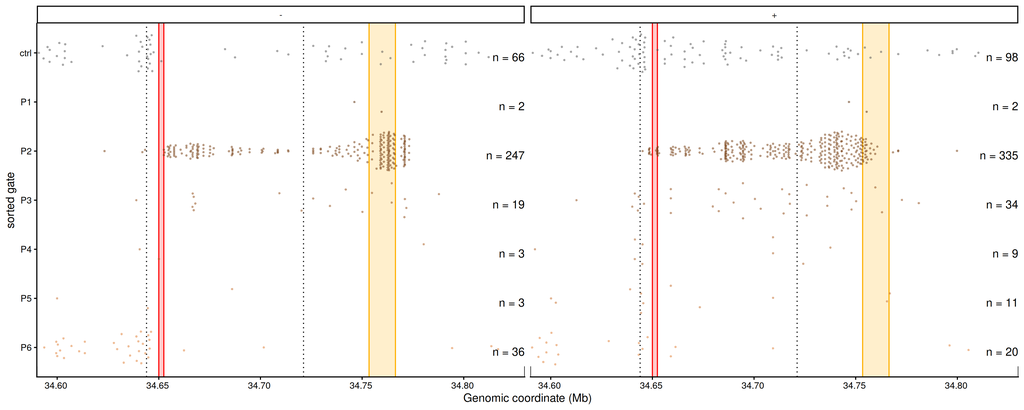

```r
# Plot 3xCBS_Rv_Sox2P stranded
pBS_3xCBS_Rv_Sox2P_stranded =
plot_beeswarm_only_stranded(TIB = tib_filtered_curated_strict %>%
                              filter(hopped & chr == "chr3" & experiment %in% all_exp) %>%
                              droplevels(),
                   CL = c("23_MK02_C2"),
                   SPLIT_STRAND = T,
                   PLOT_ANNOT = T,
                   PLOT_CTCF = F,
                   P_RANGE = prange_zoom_paper,
                   POINT_SIZE = 1.5,
                   NEXT_RANGE = prange_zoom_paper
                   )
pBS_3xCBS_Rv_Sox2P_stranded
```

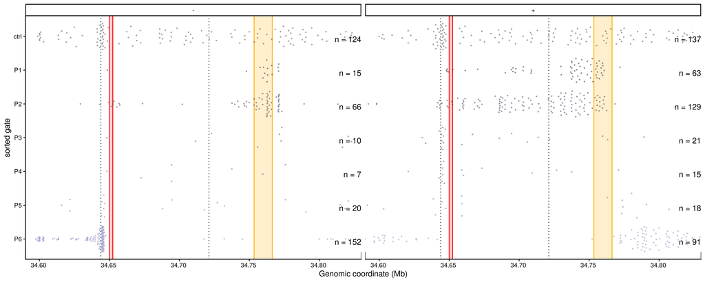

```r
# Plot 1xCBS_Fw_Sox2P stranded
pBS_1xCBS_Fw_Sox2P_stranded =
plot_beeswarm_only_stranded(TIB = tib_filtered_curated_strict %>%
                              filter(hopped & chr == "chr3" & experiment %in% all_exp) %>%
                              droplevels(),
                   CL = c("23_MK03_C1"),
                   SPLIT_STRAND = T,
                   PLOT_ANNOT = T,
                   PLOT_CTCF = F,
                   P_RANGE = prange_zoom_paper,
                   POINT_SIZE = 1.5,
                   NEXT_RANGE = prange_zoom_paper
)
pBS_1xCBS_Fw_Sox2P_stranded
```

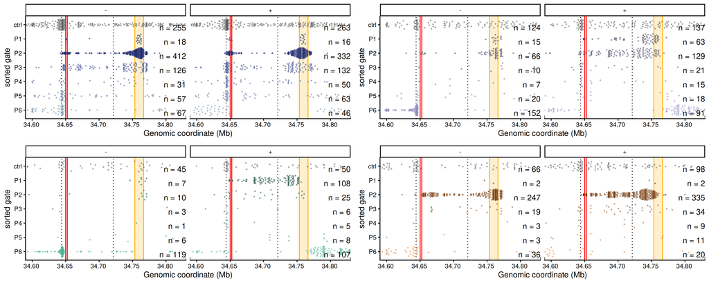

```r
# Plot stranded integrations together
plot_grid(pBS_Sox2P_stranded, pBS_1xCBS_Fw_Sox2P_stranded, pBS_3xCBS_Fw_Sox2P_stranded,pBS_3xCBS_Rv_Sox2P_stranded, ncol = 2, axis = "lb", align = "vh")
```

#Expression score ## Sox2P

```r
#all combined, 5kb window
set.seed(20240331)
min_ints_window = 3
N_bootstrap = 1000
BinSize = 1000
all_exp = unique(tib_filtered_FACS_vals$experiment)

tib_filtered_FACS_vals_comb = tib_filtered_FACS_vals %>% left_join(sorting_stats_tib_repcor)
#saveRDS(tib_filtered_FACS_vals_comb, "/DATA/projects/CTCF_Sox2/analysis/RDS_files/tib_filtered_FACS_vals_comb.rds")

#calculate running mean on random sample of same size, 1000 times
# expr_score_tib_23_34A = create_bootstrap_tibble(FUN = function(TIB){expr_score_function_new_weigh(TIB,
#                                                                                               binsize = BinSize,
#                                                                                               N_bins_window = 10,
#                                                                                               calculation_window =  prange_zoom,
#                                                                                               CL = "23_34A", EXP = all_exp)},
#                                             TIB = tib_filtered_FACS_vals_comb,
#                                             N_resamples = N_bootstrap)

#saveRDS(expr_score_tib_23_34A, "/DATA/projects/CTCF_Sox2/analysis/expression_score_new/ME20250708_new_expression_score_23_34A.rds")
expr_score_tib_23_34A = readRDS("/DATA/projects/CTCF_Sox2/analysis/expression_score_new/ME20250708_new_expression_score_23_34A.rds")

expr_score_sum_tib_23_34A = bootstrap_summary_fun(expr_score_tib_23_34A,
                                           score_column = "expr_score_window",
                                           conf_int = 0.95)

#calculate actual expr score (for filtering # of ints per window)
expr_score_real_23_34A =
  expr_score_function_new_weigh(tib_filtered_FACS_vals_comb,
                                binsize = BinSize,
                                N_bins_window = 10,
                                calculation_window =  prange_zoom,
                                CL = "23_34A",
                                EXP = all_exp)

expr_score_sum_tib_filt_comb_23_34A = left_join(expr_score_sum_tib_23_34A,  expr_score_real_23_34A) %>%
  mutate(expr_score_window_median_sel = case_when(
    total_ints_window >= min_ints_window ~ expr_score_window_median,
    .default = NA),
    expr_score_window_lower_sel = case_when(
      total_ints_window >= min_ints_window ~ expr_score_window_lower,
      .default = NA),
    expr_score_window_upper_sel = case_when(
      total_ints_window >= min_ints_window ~ expr_score_window_upper,
      .default = NA))
```

### Figure 2D

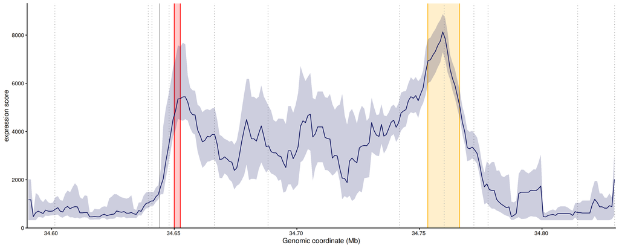

```r
pExpr_23_34A =
ggplot(expr_score_sum_tib_filt_comb_23_34A, aes(x = mid_interval)) +
  # annotate enhancer
  list(
    annotate("rect", xmin = start(enhancer), xmax = end(enhancer), ymin = -Inf, ymax = Inf, alpha = .2, fill = brown),
    geom_vline(xintercept = c(start(enhancer), end(enhancer)), col = brown),
    # annotate gene
    annotate("rect", xmin = start(Sox2_gene), xmax = end(Sox2_gene), ymin = -Inf, ymax = Inf,alpha = .2, fill = 'red'),
    geom_vline(xintercept = c(start(Sox2_gene), end(Sox2_gene)), col = 'red'),
    geom_vline(xintercept = start(landingPad_23), col = 'darkgrey'),
    geom_vline(xintercept = start(CTCF_mm10.chr3_extra), col = 'darkgrey', linetype = 'dotted')
  ) +

  ## plot the confidence interval based on the resampled data
  geom_ribbon(aes(ymin = expr_score_window_lower_sel, ymax = expr_score_window_upper_sel), alpha = 0.2, fill = "#080E5B") +
  #geom_line( aes(y = expr_score_window_mean), col = "orange") +
  ## plot the median based on the resampled data
  geom_line(aes(y = expr_score_window_median_sel), col = "#080E5B") +

  #axes
  scale_x_continuous(breaks = scales::pretty_breaks(n = 6), labels = scales::unit_format(scale = 1E-6, accuracy = 0.01, unit=NULL),
                     limits=prange_zoom_paper, expand=c(0,0)) +
  scale_y_continuous(expand=expansion(mult = c(0, 0.05)),
                     breaks = scales::pretty_breaks(n=6),
                     limits = c(0, NA)) +
  labs(x='Genomic coordinate (Mb)',y='expression score') +
  theme_classic(base_size = 16) +
  theme(legend.position = 'none')

pExpr_23_34A
```

## 3xCBS_Fw_Sox2P

```r
#all combined, 5kb window
set.seed(20240331)
min_ints_window = 3
N_bootstrap = 1000
BinSize = 1000
all_exp = unique(tib_filtered_curated_strict$experiment)

tib_filtered_FACS_vals_comb = tib_filtered_FACS_vals %>% left_join(sorting_stats_tib_repcor)


# calculate running mean on random sample of same size, 500 times
# expr_score_tib_23_MK01_C5 = create_bootstrap_tibble(FUN = function(TIB){expr_score_function_new_weigh(TIB,
#                                                                                               binsize = BinSize,
#                                                                                               N_bins_window = 10,
#                                                                                               calculation_window =  prange_zoom,
#                                                                                               CL = "23_MK01_C5", EXP = all_exp)},
#                                             TIB = tib_filtered_FACS_vals_comb,
#                                             N_resamples = N_bootstrap)
#
# saveRDS(expr_score_tib_23_MK01_C5, "/DATA/projects/CTCF_Sox2/analysis/expression_score_new/ME20250708_new_expression_score_23_MK01_C5.rds")
expr_score_tib_23_MK01_C5 = readRDS("/DATA/projects/CTCF_Sox2/analysis/expression_score_new/ME20250708_new_expression_score_23_MK01_C5.rds")

expr_score_sum_tib_23_MK01_C5 = bootstrap_summary_fun(expr_score_tib_23_MK01_C5,
                                           score_column = "expr_score_window",
                                           conf_int = 0.95)

#calculate actual expr score (for filtering # of ints per window)
expr_score_real_23_MK01_C5 =
  expr_score_function_new_weigh(tib_filtered_FACS_vals_comb,
                                binsize = BinSize,
                                N_bins_window = 10,
                                calculation_window =  prange_zoom,
                                CL = "23_MK01_C5",
                                EXP = all_exp)

expr_score_sum_tib_filt_comb_23_MK01_C5 = left_join(expr_score_sum_tib_23_MK01_C5,  expr_score_real_23_MK01_C5) %>%
  mutate(expr_score_window_median_sel = case_when(
    total_ints_window >= min_ints_window ~ expr_score_window_median,
    .default = NA),
    expr_score_window_lower_sel = case_when(
      total_ints_window >= min_ints_window ~ expr_score_window_lower,
      .default = NA),
    expr_score_window_upper_sel = case_when(
      total_ints_window >= min_ints_window ~ expr_score_window_upper,
      .default = NA))
```

### Figure S2A

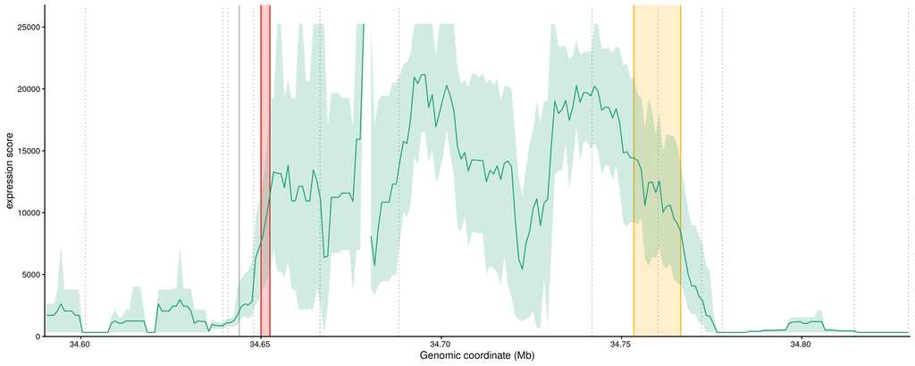

```r
pExpr_23_MK01_C5 =
ggplot(expr_score_sum_tib_filt_comb_23_MK01_C5, aes(x = mid_interval)) +
  # annotate enhancer
  list(
    annotate("rect", xmin = start(enhancer), xmax = end(enhancer), ymin = -Inf, ymax = Inf, alpha = .2, fill = brown),
    geom_vline(xintercept = c(start(enhancer), end(enhancer)), col = brown),
    # annotate gene
    annotate("rect", xmin = start(Sox2_gene), xmax = end(Sox2_gene), ymin = -Inf, ymax = Inf,alpha = .2, fill = 'red'),
    geom_vline(xintercept = c(start(Sox2_gene), end(Sox2_gene)), col = 'red'),
    geom_vline(xintercept = start(landingPad_23), col = 'darkgrey'),
    geom_vline(xintercept = start(CTCF_mm10.chr3_extra), col = 'darkgrey',linetype = 'dotted')
  ) +

  ## plot the confidence interval based on the resampled data
  geom_ribbon(aes(ymin = expr_score_window_lower_sel, ymax = expr_score_window_upper_sel), alpha = 0.2, fill = "#1b9e77") +
  #geom_line( aes(y = expr_score_window_mean), col = 'orange') +
  ## plot the median based on the resampled data
  geom_line(aes(y = expr_score_window_median_sel), col = "#1b9e77") +

  #axes
  scale_x_continuous(breaks = scales::pretty_breaks(n = 6), labels = scales::unit_format(scale = 1E-6, accuracy = 0.01, unit=NULL),
                     limits=prange_zoom_paper, expand=c(0,0)) +
  scale_y_continuous(expand=expansion(mult = c(0, 0.05)),
                     breaks = scales::pretty_breaks(n=6),
                     limits = c(0, 25500)) +
  labs(x='Genomic coordinate (Mb)',y='expression score') +
  theme_classic(base_size = 16) +
  theme(legend.position = 'none')


pExpr_23_MK01_C5
```

## 3xCBS_Rv_Sox2P

```r
#all combined, 5kb window
set.seed(20240331)
min_ints_window = 3
N_bootstrap = 1000
BinSize = 1000
all_exp = unique(tib_filtered_curated_strict$experiment)

tib_filtered_FACS_vals_comb = tib_filtered_FACS_vals %>% left_join(sorting_stats_tib_repcor)


# calculate running mean on random sample of same size, 500 times
# expr_score_tib_23_MK02_C2 = create_bootstrap_tibble(FUN = function(TIB){expr_score_function_new_weigh(TIB,
#                                                                                               binsize = BinSize,
#                                                                                               N_bins_window = 10,
#                                                                                               calculation_window =  prange_zoom,
#                                                                                               CL = "23_MK02_C2", EXP = all_exp)},
#                                             TIB = tib_filtered_FACS_vals_comb,
#
#                                                                                      N_resamples = N_bootstrap)
# saveRDS(expr_score_tib_23_MK02_C2, "/DATA/projects/CTCF_Sox2/analysis/expression_score_new/ME20250708_new_expression_score_23_MK02_C2.rds")
expr_score_tib_23_MK02_C2 = readRDS("/DATA/projects/CTCF_Sox2/analysis/expression_score_new/ME20250708_new_expression_score_23_MK02_C2.rds")



expr_score_sum_tib_23_MK02_C2 = bootstrap_summary_fun(expr_score_tib_23_MK02_C2,
                                           score_column = "expr_score_window",
                                           conf_int = 0.95)

#calculate actual expr score (for filtering # of ints per window)
expr_score_real_23_MK02_C2 =
  expr_score_function_new_weigh(tib_filtered_FACS_vals_comb,
                                binsize = BinSize,
                                N_bins_window = 10,
                                calculation_window =  prange_zoom,
                                CL = "23_MK02_C2",
                                EXP = all_exp)

expr_score_sum_tib_filt_comb_23_MK02_C2 = left_join(expr_score_sum_tib_23_MK02_C2,  expr_score_real_23_MK02_C2) %>%
  mutate(expr_score_window_median_sel = case_when(
    total_ints_window >= min_ints_window ~ expr_score_window_median,
    .default = NA),
    expr_score_window_lower_sel = case_when(
      total_ints_window >= min_ints_window ~ expr_score_window_lower,
      .default = NA),
    expr_score_window_upper_sel = case_when(
      total_ints_window >= min_ints_window ~ expr_score_window_upper,
      .default = NA))
```

### Figure S2A

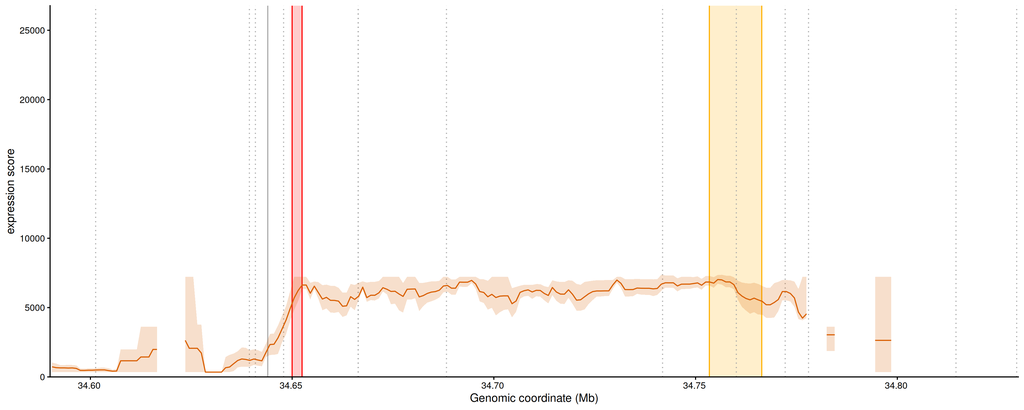

```r
pExpr_23_MK02_C2 =
ggplot(expr_score_sum_tib_filt_comb_23_MK02_C2, aes(x = mid_interval)) +
  # annotate enhancer
  list(
    annotate("rect", xmin = start(enhancer), xmax = end(enhancer), ymin = -Inf, ymax = Inf, alpha = .2, fill = brown),
    geom_vline(xintercept = c(start(enhancer), end(enhancer)), col = brown),
    # annotate gene
    annotate("rect", xmin = start(Sox2_gene), xmax = end(Sox2_gene), ymin = -Inf, ymax = Inf,alpha = .2, fill = 'red'),
    geom_vline(xintercept = c(start(Sox2_gene), end(Sox2_gene)), col = 'red'),
    geom_vline(xintercept = start(landingPad_23), col = 'darkgrey'),
    geom_vline(xintercept = start(CTCF_mm10.chr3_extra), col = 'darkgrey',linetype = 'dotted')
  ) +

  ## plot the confidence interval based on the resampled data
  geom_ribbon(aes(ymin = expr_score_window_lower_sel, ymax = expr_score_window_upper_sel), alpha = 0.2, fill = "#d95f02") +
  #geom_line( aes(y = expr_score_window_mean), col = 'orange') +
  ## plot the median based on the resampled data
  geom_line(aes(y = expr_score_window_median_sel), col = "#d95f02") +

  #axes
  scale_x_continuous(breaks = scales::pretty_breaks(n = 6), labels = scales::unit_format(scale = 1E-6, accuracy = 0.01, unit=NULL),
                     limits=prange_zoom_paper, expand=c(0,0)) +
  scale_y_continuous(expand=expansion(mult = c(0, 0.05)),
                     breaks = scales::pretty_breaks(n=6),
                     limits = c(0, 25500)) +
  labs(x='Genomic coordinate (Mb)',y='expression score') +
  theme_classic(base_size = 16) +
  theme(legend.position = 'none')

pExpr_23_MK02_C2
```

## 1xCBS_Fw_Sox2P

```r
#all combined, 5kb window
set.seed(20240331)
min_ints_window = 3
N_bootstrap = 1000
BinSize = 1000
all_exp = unique(tib_filtered_curated_strict$experiment)

tib_filtered_FACS_vals_comb = tib_filtered_FACS_vals %>% left_join(sorting_stats_tib_repcor)


# calculate running mean on random sample of same size, 500 times
# expr_score_tib_23_MK03_C1 = create_bootstrap_tibble(FUN = function(TIB){expr_score_function_new_weigh(TIB,
#                                                                                                       binsize = BinSize,
#                                                                                                       N_bins_window = 10,
#                                                                                                       calculation_window =  prange_zoom,
#                                                                                                       CL = "23_MK03_C1", EXP = all_exp)},
#                                                     TIB = tib_filtered_FACS_vals_comb,
#                                                     N_resamples = N_bootstrap)
#
# saveRDS(expr_score_tib_23_MK03_C1, "/DATA/projects/CTCF_Sox2/analysis/expression_score_new/ME20250708_new_expression_score_23_MK03_C1.rds")
expr_score_tib_23_MK03_C1 = readRDS("/DATA/projects/CTCF_Sox2/analysis/expression_score_new/ME20250708_new_expression_score_23_MK03_C1.rds")



expr_score_sum_tib_23_MK03_C1 = bootstrap_summary_fun(expr_score_tib_23_MK03_C1,
                                           score_column = "expr_score_window",
                                           conf_int = 0.95)

#calculate actual expr score (for filtering # of ints per window)
expr_score_real_23_MK03_C1 =
  expr_score_function_new_weigh(tib_filtered_FACS_vals_comb,
                                binsize = BinSize,
                                N_bins_window = 10,
                                calculation_window =  prange_zoom,
                                CL = "23_MK03_C1",
                                EXP = all_exp)

expr_score_sum_tib_filt_comb_23_MK03_C1 = left_join(expr_score_sum_tib_23_MK03_C1,  expr_score_real_23_MK03_C1) %>%
  mutate(expr_score_window_median_sel = case_when(
    total_ints_window >= min_ints_window ~ expr_score_window_median,
    .default = NA),
    expr_score_window_lower_sel = case_when(
      total_ints_window >= min_ints_window ~ expr_score_window_lower,
      .default = NA),
    expr_score_window_upper_sel = case_when(
      total_ints_window >= min_ints_window ~ expr_score_window_upper,
      .default = NA))
```

### Figure S2A

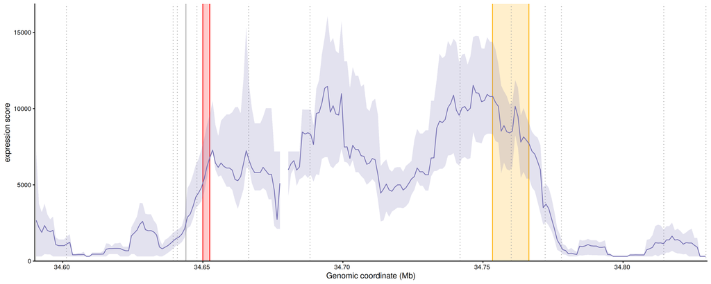

```r
pExpr_23_MK03_C1 =
ggplot(expr_score_sum_tib_filt_comb_23_MK03_C1, aes(x = mid_interval)) +
  # annotate enhancer
  list(
    annotate("rect", xmin = start(enhancer), xmax = end(enhancer), ymin = -Inf, ymax = Inf, alpha = .2, fill = brown),
    geom_vline(xintercept = c(start(enhancer), end(enhancer)), col = brown),
    # annotate gene
    annotate("rect", xmin = start(Sox2_gene), xmax = end(Sox2_gene), ymin = -Inf, ymax = Inf,alpha = .2, fill = 'red'),
    geom_vline(xintercept = c(start(Sox2_gene), end(Sox2_gene)), col = 'red'),
    geom_vline(xintercept = start(landingPad_23), col = 'darkgrey'),
    geom_vline(xintercept = start(CTCF_mm10.chr3_extra), col = 'darkgrey',linetype = 'dotted')
  ) +

  ## plot the confidence interval based on the resampled data
  geom_ribbon(aes(ymin = expr_score_window_lower_sel, ymax = expr_score_window_upper_sel), alpha = 0.2, fill = "#7570b3") +
  #geom_line( aes(y = expr_score_window_mean), col = 'orange') +
  ## plot the median based on the resampled data
  geom_line(aes(y = expr_score_window_median_sel), col = "#7570b3") +

  #axes
  scale_x_continuous(breaks = scales::pretty_breaks(n = 6), labels = scales::unit_format(scale = 1E-6, accuracy = 0.01, unit=NULL),
                     limits=prange_zoom_paper, expand=c(0,0)) +
  scale_y_continuous(expand=expansion(mult = c(0, 0.05)),
                     breaks = scales::pretty_breaks(n=6),
                     limits = c(0, NA)) +
  labs(x='Genomic coordinate (Mb)',y='expression score') +
  theme_classic(base_size = 16) +
  theme(legend.position = 'none')

pExpr_23_MK03_C1
```

### Plot together S2A

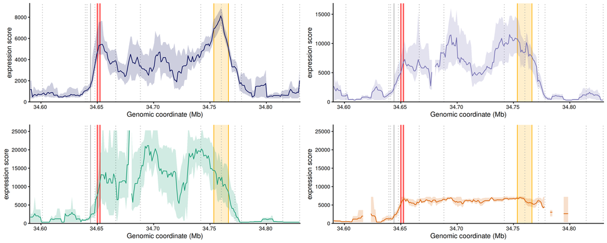

```r
plot_grid(pExpr_23_34A, pExpr_23_MK03_C1, pExpr_23_MK01_C5, pExpr_23_MK02_C2, ncol = 2, axis = "lb", align = "vh")
```

#Stranded - Expression score ## Sox2P

```r
#all combined, 5kb window
set.seed(20240331)
min_ints_window = 3
N_bootstrap = 1000
BinSize = 2000
all_exp = unique(tib_filtered_FACS_vals$experiment)


# calculate running mean on random sample of same size, 1000 times
# expr_score_tib_23_34A_str = create_bootstrap_tibble(FUN = function(TIB){expr_score_function_new_weigh_stranded(TIB,
#                                                                                               binsize = BinSize,
#                                                                                               N_bins_window = 10,
#                                                                                               calculation_window =  prange_zoom,
#                                                                                               CL = "23_34A", EXP = all_exp)},
#                                             TIB = tib_filtered_FACS_vals_comb,
#                                             N_resamples = N_bootstrap)

# saveRDS(expr_score_tib_23_34A_str, "/DATA/projects/CTCF_Sox2/analysis/expression_score_new/ME20250708_new_expression_score_23_34A_str.rds")
expr_score_tib_23_34A_str = readRDS("/DATA/projects/CTCF_Sox2/analysis/expression_score_new/ME20250708_new_expression_score_23_34A_str.rds")



expr_score_sum_tib_23_34A_str = bootstrap_summary_fun_str(expr_score_tib_23_34A_str,
                                           score_column = "expr_score_window",
                                           conf_int = 0.95)

#calculate actual expr score (for filtering # of ints per window)
expr_score_real_23_34A_str =
  expr_score_function_new_weigh_stranded(tib_filtered_FACS_vals_comb,
                                binsize = BinSize,
                                N_bins_window = 10,
                                calculation_window =  prange_zoom,
                                CL = "23_34A",
                                EXP = all_exp)

expr_score_sum_tib_filt_comb_23_34A_str = left_join(expr_score_sum_tib_23_34A_str,  expr_score_real_23_34A_str) %>%
  mutate(expr_score_window_median_sel = case_when(
    total_ints_window >= min_ints_window ~ expr_score_window_median,
    .default = NA),
    expr_score_window_lower_sel = case_when(
      total_ints_window >= min_ints_window ~ expr_score_window_lower,
      .default = NA),
    expr_score_window_upper_sel = case_when(
      total_ints_window >= min_ints_window ~ expr_score_window_upper,
      .default = NA))
```

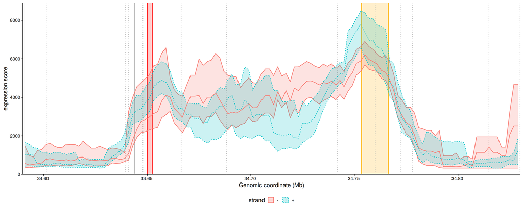

```r
pExpr_23_34A_str =
ggplot(expr_score_sum_tib_filt_comb_23_34A_str, aes(x = mid_interval, col = strand, fill = strand, linetype = strand)) +
  # annotate enhancer
  list(
    annotate("rect", xmin = start(enhancer), xmax = end(enhancer), ymin = -Inf, ymax = Inf, alpha = .2, fill = brown),
    geom_vline(xintercept = c(start(enhancer), end(enhancer)), col = brown),
    # annotate gene
    annotate("rect", xmin = start(Sox2_gene), xmax = end(Sox2_gene), ymin = -Inf, ymax = Inf,alpha = .2, fill = 'red'),
    geom_vline(xintercept = c(start(Sox2_gene), end(Sox2_gene)), col = 'red'),
    geom_vline(xintercept = start(landingPad_23), col = 'darkgrey'),
    geom_vline(xintercept = start(CTCF_mm10.chr3_extra), col = 'darkgrey',linetype = 'dotted')
  ) +

  ## plot the confidence interval based on the resampled data
  geom_ribbon(aes(ymin = expr_score_window_lower_sel, ymax = expr_score_window_upper_sel), alpha = 0.2) +
  #geom_line( aes(y = expr_score_window_mean), col = "orange") +
  ## plot the median based on the resampled data
  geom_line(aes(y = expr_score_window_median_sel)) +

  #axes
  scale_x_continuous(breaks = scales::pretty_breaks(n = 6), labels = scales::unit_format(scale = 1E-6, accuracy = 0.01, unit=NULL),
                     limits=prange_zoom_paper, expand=c(0,0)) +
  scale_y_continuous(expand=expansion(mult = c(0, 0.05)),
                     breaks = scales::pretty_breaks(n=6),
                     limits = c(0, NA)) +
  labs(x='Genomic coordinate (Mb)',y='expression score') +
  theme_classic(base_size = 16) +
  theme(legend.position = 'bottom')

pExpr_23_34A_str
```

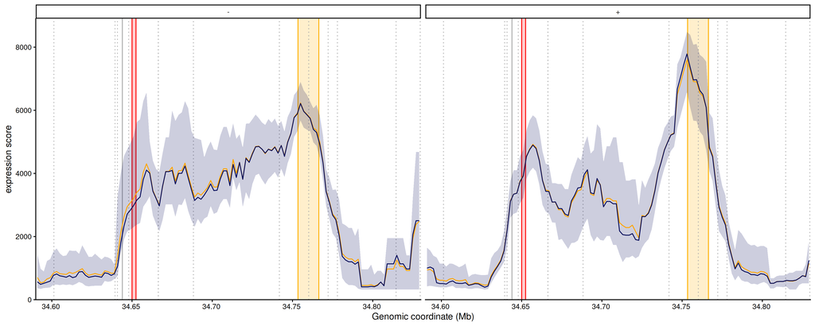

```r
## split by strand
pExpr_23_34A_str_facet =
ggplot(expr_score_sum_tib_filt_comb_23_34A_str, aes(x = mid_interval)) +
  facet_grid(. ~ strand) +
  # annotate enhancer
  list(
    annotate("rect", xmin = start(enhancer), xmax = end(enhancer), ymin = -Inf, ymax = Inf, alpha = .2, fill = brown),
    geom_vline(xintercept = c(start(enhancer), end(enhancer)), col = brown),
    # annotate gene
    annotate("rect", xmin = start(Sox2_gene), xmax = end(Sox2_gene), ymin = -Inf, ymax = Inf,alpha = .2, fill = 'red'),
    geom_vline(xintercept = c(start(Sox2_gene), end(Sox2_gene)), col = 'red'),
    geom_vline(xintercept = start(landingPad_23), col = 'darkgrey'),
    geom_vline(xintercept = start(CTCF_mm10.chr3_extra), col = 'darkgrey',linetype = 'dotted')
  ) +

  ## plot the confidence interval based on the resampled data
  geom_ribbon(aes(ymin = expr_score_window_lower_sel, ymax = expr_score_window_upper_sel), alpha = 0.2, fill = "#080E5B") +
  geom_line( aes(y = expr_score_window_mean), col = "orange") +
  ## plot the median based on the resampled data
  geom_line(aes(y = expr_score_window_median_sel), col = "#080E5B") +

  #axes
  scale_x_continuous(breaks = scales::pretty_breaks(n = 6), labels = scales::unit_format(scale = 1E-6, accuracy = 0.01, unit=NULL),
                     limits=prange_zoom_paper, expand=c(0,0)) +
  scale_y_continuous(expand=expansion(mult = c(0, 0.05)),
                     breaks = scales::pretty_breaks(n=6),
                     limits = c(0, NA)) +
  labs(x='Genomic coordinate (Mb)',y='expression score') +
  theme_classic(base_size = 16) +
  theme(legend.position = 'bottom')

pExpr_23_34A_str_facet
```

## 3xCBS_Fw_Sox2P

```r
#all combined, 5kb window
set.seed(20240331)
min_ints_window = 3
N_bootstrap = 1000
BinSize = 2000
all_exp = unique(tib_filtered_curated_strict$experiment)

tib_filtered_FACS_vals_comb = tib_filtered_FACS_vals %>% left_join(sorting_stats_tib_repcor)


# calculate running mean on random sample of same size, 500 times
# expr_score_tib_23_MK01_C5_str = create_bootstrap_tibble(FUN = function(TIB){expr_score_function_new_weigh_stranded(TIB,
#                                                                                               binsize = BinSize,
#                                                                                               N_bins_window = 10,
#                                                                                               calculation_window =  prange_zoom,
#                                                                                               CL = "23_MK01_C5",
#                                                                                               EXP = all_exp)},
#                                             TIB = tib_filtered_FACS_vals_comb,
#                                             N_resamples = N_bootstrap)

#saveRDS(expr_score_tib_23_MK01_C5_str, "/DATA/projects/CTCF_Sox2/analysis/expression_score_new/ME20250708_new_expression_score_23_MK01_C5_str.rds")
expr_score_tib_23_MK01_C5_str = readRDS("/DATA/projects/CTCF_Sox2/analysis/expression_score_new/ME20250708_new_expression_score_23_MK01_C5_str.rds")

expr_score_sum_tib_23_MK01_C5 = bootstrap_summary_fun_str(expr_score_tib_23_MK01_C5_str,
                                           score_column = "expr_score_window",
                                           conf_int = 0.95)

#calculate actual expr score (for filtering # of ints per window)
expr_score_real_23_MK01_C5 =
  expr_score_function_new_weigh_stranded(tib_filtered_FACS_vals_comb,
                                binsize = BinSize,
                                N_bins_window = 10,
                                calculation_window =  prange_zoom,
                                CL = "23_MK01_C5",
                                EXP = all_exp)

expr_score_sum_tib_filt_comb_23_MK01_C5_str = left_join(expr_score_sum_tib_23_MK01_C5,  expr_score_real_23_MK01_C5) %>%
  mutate(expr_score_window_median_sel = case_when(
    total_ints_window >= min_ints_window ~ expr_score_window_median,
    .default = NA),
    expr_score_window_lower_sel = case_when(
      total_ints_window >= min_ints_window ~ expr_score_window_lower,
      .default = NA),
    expr_score_window_upper_sel = case_when(
      total_ints_window >= min_ints_window ~ expr_score_window_upper,
      .default = NA))
```

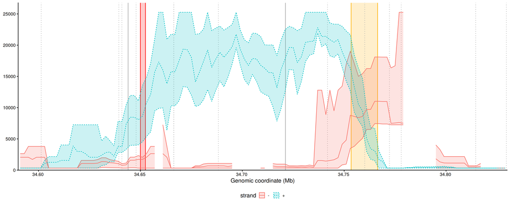

```r
pExpr_23_MK01_C5_str =
ggplot(expr_score_sum_tib_filt_comb_23_MK01_C5_str, aes(x = mid_interval, col = strand, fill = strand, linetype = strand)) +
  # annotate enhancer
  list(
    annotate("rect", xmin = start(enhancer), xmax = end(enhancer), ymin = -Inf, ymax = Inf, alpha = .2, fill = brown),
    geom_vline(xintercept = c(start(enhancer), end(enhancer)), col = brown),
    # annotate gene
    annotate("rect", xmin = start(Sox2_gene), xmax = end(Sox2_gene), ymin = -Inf, ymax = Inf,alpha = .2, fill = 'red'),
    geom_vline(xintercept = c(start(Sox2_gene), end(Sox2_gene)), col = 'red'),
    geom_vline(xintercept = start(landingPad_23), col = 'darkgrey'),
    geom_vline(xintercept = start(landingPad_8), col = 'darkgrey'),
    geom_vline(xintercept = start(CTCF_mm10.chr3_extra), col = 'darkgrey',linetype = 'dotted')
  ) +

  ## plot the confidence interval based on the resampled data
  geom_ribbon(aes(ymin = expr_score_window_lower_sel, ymax = expr_score_window_upper_sel), alpha = 0.2) +
  #geom_line( aes(y = expr_score_window_mean), col = 'orange') +
  ## plot the median based on the resampled data
  geom_line(aes(y = expr_score_window_median_sel)) +

  #axes
  scale_x_continuous(breaks = scales::pretty_breaks(n = 6), labels = scales::unit_format(scale = 1E-6, accuracy = 0.01, unit=NULL),
                     limits=prange_zoom_paper, expand=c(0,0)) +
  scale_y_continuous(expand=expansion(mult = c(0, 0.05)),
                     breaks = scales::pretty_breaks(n=6),
                     limits = c(0, 25500)) +
  labs(x='Genomic coordinate (Mb)',y='expression score') +
  theme_classic(base_size = 16) +
  theme(legend.position = 'bottom') +
  theme(axis.title.y=element_blank())

pExpr_23_MK01_C5_str
```

## 3xCBS_Rv_Sox2P

```r
#all combined, 5kb window
set.seed(20240331)
min_ints_window = 2
N_bootstrap = 1000
BinSize = 2000
all_exp = unique(tib_filtered_curated_strict$experiment)

tib_filtered_FACS_vals_comb = tib_filtered_FACS_vals %>% left_join(sorting_stats_tib_repcor)


#calculate running mean on random sample of same size, 500 times
# expr_score_tib_23_MK02_C2_str = create_bootstrap_tibble(FUN = function(TIB){expr_score_function_new_weigh_stranded(TIB,
#                                                                                               binsize = BinSize,
#                                                                                               N_bins_window = 10,
#                                                                                               calculation_window =  prange_zoom,
#                                                                                               CL = "23_MK02_C2", EXP = all_exp)},
#                                             TIB = tib_filtered_FACS_vals_comb,
#
#                                                                                      N_resamples = N_bootstrap)
# saveRDS(expr_score_tib_23_MK02_C2_str, "/DATA/projects/CTCF_Sox2/analysis/expression_score_new/ME20250708_new_expression_score_23_MK02_C2_str.rds")
expr_score_tib_23_MK02_C2_str = readRDS("/DATA/projects/CTCF_Sox2/analysis/expression_score_new/ME20250708_new_expression_score_23_MK02_C2_str.rds")



expr_score_sum_tib_23_MK02_C2 = bootstrap_summary_fun_str(expr_score_tib_23_MK02_C2_str,
                                           score_column = "expr_score_window",
                                           conf_int = 0.95)

#calculate actual expr score (for filtering # of ints per window)
expr_score_real_23_MK02_C2_str =
  expr_score_function_new_weigh_stranded(tib_filtered_FACS_vals_comb,
                                binsize = BinSize,
                                N_bins_window = 10,
                                calculation_window =  prange_zoom,
                                CL = "23_MK02_C2",
                                EXP = all_exp)

expr_score_sum_tib_filt_comb_23_MK02_C2_str = left_join(expr_score_sum_tib_23_MK02_C2,  expr_score_real_23_MK02_C2_str) %>%
  mutate(expr_score_window_median_sel = case_when(
    total_ints_window >= min_ints_window ~ expr_score_window_median,
    .default = NA),
    expr_score_window_lower_sel = case_when(
      total_ints_window >= min_ints_window ~ expr_score_window_lower,
      .default = NA),
    expr_score_window_upper_sel = case_when(
      total_ints_window >= min_ints_window ~ expr_score_window_upper,
      .default = NA))
```

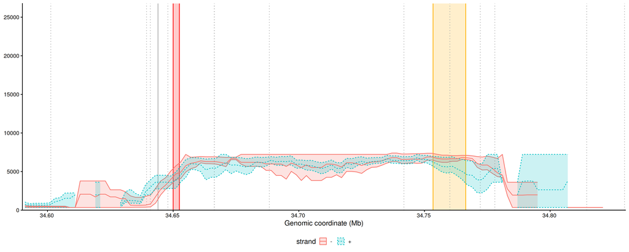

```r
pExpr_23_MK02_C2_str =
ggplot(expr_score_sum_tib_filt_comb_23_MK02_C2_str, aes(x = mid_interval, col = strand, fill = strand, linetype = strand)) +
  # annotate enhancer
  list(
    annotate("rect", xmin = start(enhancer), xmax = end(enhancer), ymin = -Inf, ymax = Inf, alpha = .2, fill = brown),
    geom_vline(xintercept = c(start(enhancer), end(enhancer)), col = brown),
    # annotate gene
    annotate("rect", xmin = start(Sox2_gene), xmax = end(Sox2_gene), ymin = -Inf, ymax = Inf,alpha = .2, fill = 'red'),
    geom_vline(xintercept = c(start(Sox2_gene), end(Sox2_gene)), col = 'red'),
    geom_vline(xintercept = start(landingPad_23), col = 'darkgrey'),
    geom_vline(xintercept = start(CTCF_mm10.chr3_extra), col = 'darkgrey',linetype = 'dotted')
  ) +

  ## plot the confidence interval based on the resampled data
  geom_ribbon(aes(ymin = expr_score_window_lower_sel, ymax = expr_score_window_upper_sel), alpha = 0.2) +
  #geom_line( aes(y = expr_score_window_mean), col = 'orange') +
  ## plot the median based on the resampled data
  geom_line(aes(y = expr_score_window_median_sel)) +

  #axes
  scale_x_continuous(breaks = scales::pretty_breaks(n = 6), labels = scales::unit_format(scale = 1E-6, accuracy = 0.01, unit=NULL),
                     limits=prange_zoom_paper, expand=c(0,0)) +
  scale_y_continuous(expand=expansion(mult = c(0, 0.05)),
                     breaks = scales::pretty_breaks(n=6),
                     limits = c(0, 25500)) +
  labs(x='Genomic coordinate (Mb)',y='expression score') +
  theme_classic(base_size = 16) +
  theme(legend.position = 'bottom') +
  theme(axis.title.y=element_blank())

pExpr_23_MK02_C2_str
```

## 1xCBS_Fw_Sox2P

```r
#all combined, 5kb window
set.seed(20240331)
min_ints_window = 3
N_bootstrap = 1000
BinSize = 2000
all_exp = unique(tib_filtered_curated_strict$experiment)

tib_filtered_FACS_vals_comb = tib_filtered_FACS_vals %>% left_join(sorting_stats_tib_repcor)


# calculate running mean on random sample of same size, 500 times
# expr_score_tib_23_MK03_C1 = create_bootstrap_tibble(FUN = function(TIB){expr_score_function_new_weigh_stranded(TIB,
#                                                                                               binsize = BinSize,
#                                                                                               N_bins_window = 10,
#                                                                                               calculation_window =  prange_zoom,
#                                                                                               CL = "23_MK03_C1", EXP = all_exp)},
#                                             TIB = tib_filtered_FACS_vals_comb,
#
#                                                                                      N_resamples = N_bootstrap)

# saveRDS(expr_score_tib_23_MK03_C1, "/DATA/projects/CTCF_Sox2/analysis/expression_score_new/ME20250708_new_expression_score_23_MK03_C1_stranded.rds")
expr_score_tib_23_MK03_C1 = readRDS("/DATA/projects/CTCF_Sox2/analysis/expression_score_new/ME20250708_new_expression_score_23_MK03_C1_stranded.rds")



expr_score_sum_tib_23_MK03_C1 = bootstrap_summary_fun_str(expr_score_tib_23_MK03_C1,
                                           score_column = "expr_score_window",
                                           conf_int = 0.95)

#calculate actual expr score (for filtering # of ints per window)
expr_score_real_23_MK03_C1_str =
  expr_score_function_new_weigh_stranded(tib_filtered_FACS_vals_comb,
                                binsize = BinSize,
                                N_bins_window = 10,
                                calculation_window =  prange_zoom,
                                CL = "23_MK03_C1",
                                EXP = all_exp)

expr_score_sum_tib_filt_comb_23_MK03_C1_str = left_join(expr_score_sum_tib_23_MK03_C1,  expr_score_real_23_MK03_C1_str) %>%
  mutate(expr_score_window_median_sel = case_when(
    total_ints_window >= min_ints_window ~ expr_score_window_median,
    .default = NA),
    expr_score_window_lower_sel = case_when(
      total_ints_window >= min_ints_window ~ expr_score_window_lower,
      .default = NA),
    expr_score_window_upper_sel = case_when(
      total_ints_window >= min_ints_window ~ expr_score_window_upper,
      .default = NA))
```

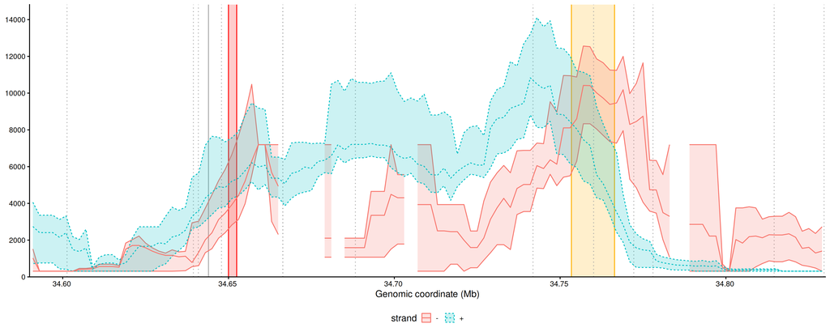

```r
pExpr_23_MK03_C1_str =
ggplot(expr_score_sum_tib_filt_comb_23_MK03_C1_str, aes(x = mid_interval,  col = strand, fill = strand, linetype = strand)) +
  # annotate enhancer
  list(
    annotate("rect", xmin = start(enhancer), xmax = end(enhancer), ymin = -Inf, ymax = Inf, alpha = .2, fill = brown),
    geom_vline(xintercept = c(start(enhancer), end(enhancer)), col = brown),
    # annotate gene
    annotate("rect", xmin = start(Sox2_gene), xmax = end(Sox2_gene), ymin = -Inf, ymax = Inf,alpha = .2, fill = 'red'),
    geom_vline(xintercept = c(start(Sox2_gene), end(Sox2_gene)), col = 'red'),
    geom_vline(xintercept = start(landingPad_23), col = 'darkgrey'),
    geom_vline(xintercept = start(CTCF_mm10.chr3_extra), col = 'darkgrey',linetype = 'dotted')
  ) +

  ## plot the confidence interval based on the resampled data
  geom_ribbon(aes(ymin = expr_score_window_lower_sel, ymax = expr_score_window_upper_sel), alpha = 0.2) +
  #geom_line( aes(y = expr_score_window_mean), col = 'orange') +
  ## plot the median based on the resampled data
  geom_line(aes(y = expr_score_window_median_sel)) +

  #axes
  scale_x_continuous(breaks = scales::pretty_breaks(n = 6), labels = scales::unit_format(scale = 1E-6, accuracy = 0.01, unit=NULL),
                     limits=prange_zoom_paper, expand=c(0,0)) +
  scale_y_continuous(expand=expansion(mult = c(0, 0.05)),
                     breaks = scales::pretty_breaks(n=6),
                     limits = c(0, NA)) +
  labs(x='Genomic coordinate (Mb)',y='expression score') +
  theme_classic(base_size = 16) +
  theme(legend.position = 'bottom') +
  theme(axis.title.y=element_blank())

pExpr_23_MK03_C1_str
```

## plot together

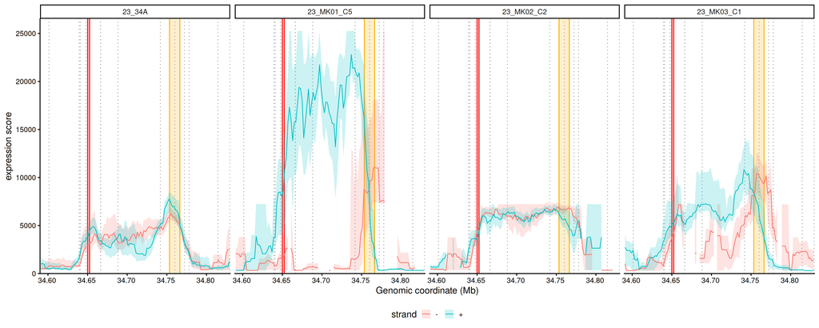

```r
expr_score_sum_per_cl_str = bind_rows(`23_34A` = expr_score_sum_tib_filt_comb_23_34A_str,
                                  `23_MK01_C5` = expr_score_sum_tib_filt_comb_23_MK01_C5_str,
                                  `23_MK02_C2` = expr_score_sum_tib_filt_comb_23_MK02_C2_str,
                                  `23_MK03_C1` = expr_score_sum_tib_filt_comb_23_MK03_C1_str,
                                  .id = 'cell_line') %>%
  mutate(cell_line = factor(cell_line, levels = c("23_34A", "23_MK01_C5", "23_MK02_C2", "23_MK03_C1")))


# Figure S2F, S2G, S2H, S2I expression scores per strand
expr_score_sum_per_cl_str %>%
  ggplot(aes(x = mid_interval)) +
  facet_grid(.~ factor(cell_line, levels = c("23_34A", "23_MK01_C5", "23_MK02_C2", "23_MK03_C1"))) +
  # annotate enhancer
  list(
    annotate("rect", xmin = start(enhancer), xmax = end(enhancer), ymin = -Inf, ymax = Inf, alpha = .2, fill = brown),
    geom_vline(xintercept = c(start(enhancer), end(enhancer)), col = brown),
    # annotate gene
    annotate("rect", xmin = start(Sox2_gene), xmax = end(Sox2_gene), ymin = -Inf, ymax = Inf,alpha = .2, fill = 'red'),
    geom_vline(xintercept = c(start(Sox2_gene), end(Sox2_gene)), col = 'red'),
    #geom_vline(data = LP_tib_for_plot, aes(xintercept = start), col = 'darkgrey'),
    geom_vline(xintercept = start(CTCF_mm10.chr3_extra), col = 'darkgrey',linetype = 'dotted')
  ) +

  ## plot the confidence interval based on the resampled data
  geom_ribbon(aes(ymin = expr_score_window_lower_sel, ymax = expr_score_window_upper_sel, fill = strand), alpha = 0.2) +
  # geom_line( aes(y = expr_score_window_mean), col = 'orange') +
  ## plot the median based on the resampled data
  geom_line(aes(y = expr_score_window_median_sel, col = strand), linewidth = 0.6) +
  #axes
  scale_x_continuous(breaks = scales::pretty_breaks(n = 6), labels = scales::unit_format(scale = 1E-6, accuracy = 0.01, unit=NULL),
                     limits=prange_zoom_paper, expand=c(0,0)) +
  scale_y_continuous(expand=expansion(mult = c(0, 0.05)),
                     breaks = scales::pretty_breaks(n=6),
                     limits = c(0, NA)) +
  labs(x='Genomic coordinate (Mb)',y='expression score') +
  theme_classic(base_size = 16) +
  theme(legend.position = 'bottom')
```

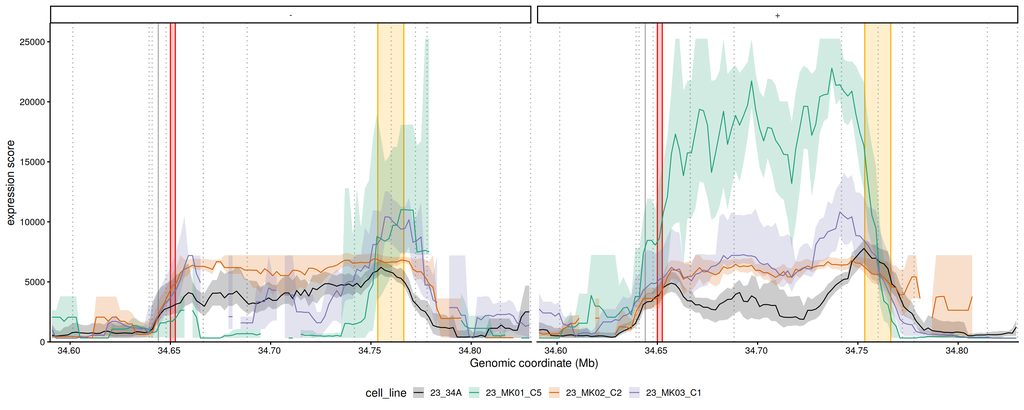

```r
# Figure S2F, S2G, S2H, S2I expression scores per strand
expr_score_sum_per_cl_str %>%
  ggplot(aes(x = mid_interval)) +
  facet_grid(. ~ strand) +
  # annotate enhancer
  list(
    annotate("rect", xmin = start(enhancer), xmax = end(enhancer), ymin = -Inf, ymax = Inf, alpha = .2, fill = brown),
    geom_vline(xintercept = c(start(enhancer), end(enhancer)), col = brown),
    # annotate gene
    annotate("rect", xmin = start(Sox2_gene), xmax = end(Sox2_gene), ymin = -Inf, ymax = Inf,alpha = .2, fill = 'red'),
    geom_vline(xintercept = c(start(Sox2_gene), end(Sox2_gene)), col = 'red'),
    # annotate LP's
    geom_vline(xintercept = start(landingPad_23), col = 'darkgrey'),
    #geom_vline(xintercept = start(landingPad_8), col = 'darkgrey'),
    #geom_vline(data = LP_tib_for_plot, aes(xintercept = start), col = 'darkgrey'),
    geom_vline(xintercept = start(CTCF_mm10.chr3_extra), col = 'darkgrey',linetype = 'dotted')
  ) +
  ## plot the confidence interval based on the resampled data
  geom_ribbon(aes(ymin = expr_score_window_lower_sel, ymax = expr_score_window_upper_sel, fill = cell_line), alpha = 0.2) +
  #geom_line( aes(y = expr_score_window_mean), col = 'orange') +
  ## plot the median based on the resampled data
  geom_line(aes(y = expr_score_window_median_sel, col = cell_line), linewidth = 0.6) +
  #axes
  scale_x_continuous(breaks = scales::pretty_breaks(n = 6), labels = scales::unit_format(scale = 1E-6, accuracy = 0.01, unit=NULL),
                     limits=prange_zoom_paper, expand=c(0,0)) +
  scale_y_continuous(expand=expansion(mult = c(0, 0.05)),
                     breaks = scales::pretty_breaks(n=6),
                     limits = c(0, NA)) +
  labs(x='Genomic coordinate (Mb)',y='expression score') +
  theme_classic(base_size = 16) +
  theme(legend.position = 'bottom') +
  col_scale_MK_CL
```

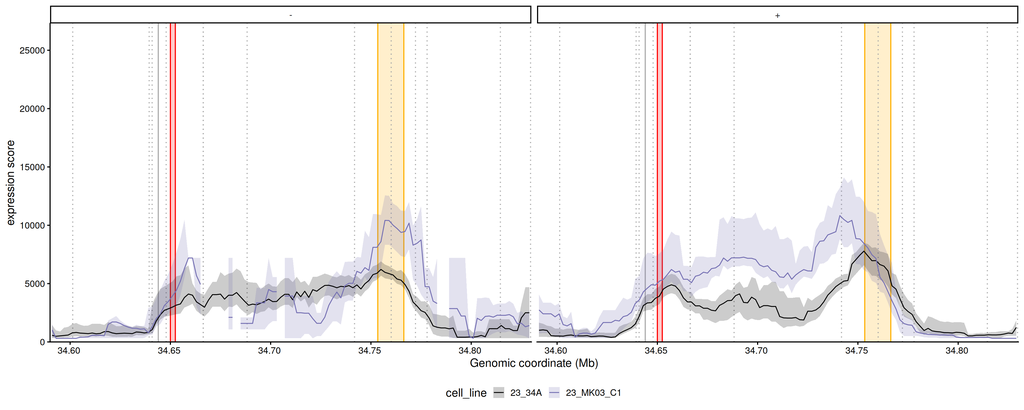

```r
expr_score_sum_per_cl_str %>%
  filter(cell_line %in% c("23_34A", "23_MK03_C1")) %>%
  ggplot(aes(x = mid_interval)) +
  facet_grid(. ~ strand) +
  # annotate enhancer
  list(
    annotate("rect", xmin = start(enhancer), xmax = end(enhancer), ymin = -Inf, ymax = Inf, alpha = .2, fill = brown),
    geom_vline(xintercept = c(start(enhancer), end(enhancer)), col = brown),
    # annotate gene
    annotate("rect", xmin = start(Sox2_gene), xmax = end(Sox2_gene), ymin = -Inf, ymax = Inf,alpha = .2, fill = 'red'),
    geom_vline(xintercept = c(start(Sox2_gene), end(Sox2_gene)), col = 'red'),
    # annotate LP's
    geom_vline(xintercept = start(landingPad_23), col = 'darkgrey'),
    #geom_vline(xintercept = start(landingPad_8), col = 'darkgrey'),
    #geom_vline(data = LP_tib_for_plot, aes(xintercept = start), col = 'darkgrey'),
    geom_vline(xintercept = start(CTCF_mm10.chr3_extra), col = 'darkgrey',linetype = 'dotted')
  ) +
  ## plot the confidence interval based on the resampled data
  geom_ribbon(aes(ymin = expr_score_window_lower_sel, ymax = expr_score_window_upper_sel, fill = cell_line), alpha = 0.2) +
  #geom_line( aes(y = expr_score_window_mean), col = 'orange') +
  ## plot the median based on the resampled data
  geom_line(aes(y = expr_score_window_median_sel, col = cell_line), linewidth = 0.6) +
  #axes
  scale_x_continuous(breaks = scales::pretty_breaks(n = 6), labels = scales::unit_format(scale = 1E-6, accuracy = 0.01, unit=NULL),
                     limits=prange_zoom_paper, expand=c(0,0)) +
  scale_y_continuous(expand=expansion(mult = c(0, 0.05)),
                     breaks = scales::pretty_breaks(n=6),
                     limits = c(0, 26e3)) +
  labs(x='Genomic coordinate (Mb)',y='expression score') +
  theme_classic(base_size = 16) +
  theme(legend.position = 'bottom') +
  col_scale_MK_CL
```

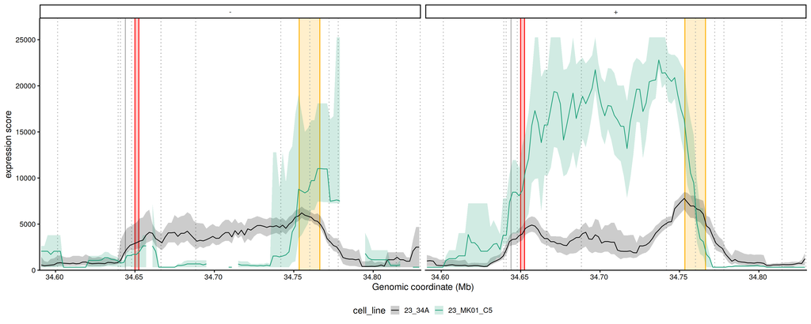

```r
expr_score_sum_per_cl_str %>%
  filter(cell_line %in% c("23_34A", "23_MK01_C5")) %>%
  ggplot(aes(x = mid_interval)) +
  facet_grid(. ~ strand) +
  # annotate enhancer
  list(
    annotate("rect", xmin = start(enhancer), xmax = end(enhancer), ymin = -Inf, ymax = Inf, alpha = .2, fill = brown),
    geom_vline(xintercept = c(start(enhancer), end(enhancer)), col = brown),
    # annotate gene
    annotate("rect", xmin = start(Sox2_gene), xmax = end(Sox2_gene), ymin = -Inf, ymax = Inf,alpha = .2, fill = 'red'),
    geom_vline(xintercept = c(start(Sox2_gene), end(Sox2_gene)), col = 'red'),
    # annotate LP's
    geom_vline(xintercept = start(landingPad_23), col = 'darkgrey'),
    #geom_vline(xintercept = start(landingPad_8), col = 'darkgrey'),
    #geom_vline(data = LP_tib_for_plot, aes(xintercept = start), col = 'darkgrey'),
    geom_vline(xintercept = start(CTCF_mm10.chr3_extra), col = 'darkgrey',linetype = 'dotted')
  ) +
  ## plot the confidence interval based on the resampled data
  geom_ribbon(aes(ymin = expr_score_window_lower_sel, ymax = expr_score_window_upper_sel, fill = cell_line), alpha = 0.2) +
  #geom_line( aes(y = expr_score_window_mean), col = 'orange') +
  ## plot the median based on the resampled data
  geom_line(aes(y = expr_score_window_median_sel, col = cell_line), linewidth = 0.6) +
  #axes
  scale_x_continuous(breaks = scales::pretty_breaks(n = 6), labels = scales::unit_format(scale = 1E-6, accuracy = 0.01, unit=NULL),
                     limits=prange_zoom_paper, expand=c(0,0)) +
  scale_y_continuous(expand=expansion(mult = c(0, 0.05)),
                     breaks = scales::pretty_breaks(n=6),
                     limits = c(0, 26e3)) +
  labs(x='Genomic coordinate (Mb)',y='expression score') +
  theme_classic(base_size = 16) +
  theme(legend.position = 'bottom') +
  col_scale_MK_CL
```

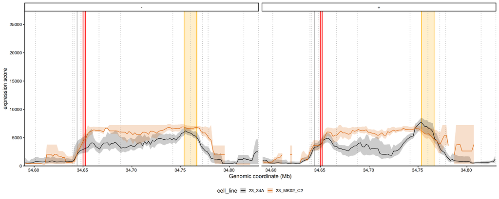

```r
expr_score_sum_per_cl_str %>%
  filter(cell_line %in% c("23_34A", "23_MK02_C2")) %>%
  ggplot(aes(x = mid_interval)) +
  facet_grid(. ~ strand) +
  # annotate enhancer
  list(
    annotate("rect", xmin = start(enhancer), xmax = end(enhancer), ymin = -Inf, ymax = Inf, alpha = .2, fill = brown),
    geom_vline(xintercept = c(start(enhancer), end(enhancer)), col = brown),
    # annotate gene
    annotate("rect", xmin = start(Sox2_gene), xmax = end(Sox2_gene), ymin = -Inf, ymax = Inf,alpha = .2, fill = 'red'),
    geom_vline(xintercept = c(start(Sox2_gene), end(Sox2_gene)), col = 'red'),
    # annotate LP's
    geom_vline(xintercept = start(landingPad_23), col = 'darkgrey'),
    #geom_vline(xintercept = start(landingPad_8), col = 'darkgrey'),
    #geom_vline(data = LP_tib_for_plot, aes(xintercept = start), col = 'darkgrey'),
    geom_vline(xintercept = start(CTCF_mm10.chr3_extra), col = 'darkgrey',linetype = 'dotted')
  ) +
  ## plot the confidence interval based on the resampled data
  geom_ribbon(aes(ymin = expr_score_window_lower_sel, ymax = expr_score_window_upper_sel, fill = cell_line), alpha = 0.2) +
  #geom_line( aes(y = expr_score_window_mean), col = 'orange') +
  ## plot the median based on the resampled data
  geom_line(aes(y = expr_score_window_median_sel, col = cell_line), linewidth = 0.6) +
  #axes
  scale_x_continuous(breaks = scales::pretty_breaks(n = 6), labels = scales::unit_format(scale = 1E-6, accuracy = 0.01, unit=NULL),
                     limits=prange_zoom_paper, expand=c(0,0)) +
  scale_y_continuous(expand=expansion(mult = c(0, 0.05)),
                     breaks = scales::pretty_breaks(n=6),
                     limits = c(0, 26e3)) +
  labs(x='Genomic coordinate (Mb)',y='expression score') +
  theme_classic(base_size = 16) +
  theme(legend.position = 'bottom') +
  col_scale_MK_CL
```

## Add DHS annotations from Brosh

### Load Brosh - Maurano annotations

```r
# =========================================================================
# Original Brosh / Maurano payload coordinates
# =========================================================================

Brosh_coordinates <- read_tsv("/DATA/projects/CTCF_Sox2/external_datasets/annotations_Brosh_paper/Maurano_genomic_coordinates_excel.tsv",
  show_col_types = FALSE)


Brosh_table_S4 <- read_tsv(  "/DATA/projects/CTCF_Sox2/external_datasets/annotations_Brosh_paper/Maurano_TableS4_excel.tsv",
  show_col_types = FALSE)

# =========================================================================
# Ribeiro dos Santos DHS / Sox2 annotation table
# PMID 41125441
# Coordinates are mm10
# =========================================================================

Ribeiro_Brosh_DHS_annotations <- read_tsv(  "/DATA/projects/CTCF_Sox2/external_datasets/annotations_Brosh_paper/Ribeiro_Dos_Santos_PMID_41125441_Supplemental_Table_S1.tsv",
  show_col_types = FALSE)


# -------------------------------------------------------------------------
# Clean Brosh Table S4 column names
# -------------------------------------------------------------------------

Brosh_table_S4 <- Brosh_table_S4 %>%
  rename(
    Payload_ID = `Payload ID`,
    Clone_ID = `Clone ID`,
    Sox2_CAST = `Sox2 (CAST)`,
    Sox2_BL6 = `Sox2 (BL6)`,
    Fold_change = `Fold change`)


Brosh_coordinates <- Brosh_coordinates %>%
  rename(chrom = `#chrom`)

# -------------------------------------------------------------------------
# Clean Ribeiro table
# -------------------------------------------------------------------------

Ribeiro_Brosh_DHS_annotations <- Ribeiro_Brosh_DHS_annotations %>%
  rename(
    chrom = `#Chrom`,
    chromStart = ChromStart,
    chromEnd = ChromEnd,
    name = Name)


# -------------------------------------------------------------------------
# Merge Brosh payload coordinates with Table S4 annotation
# -------------------------------------------------------------------------

Brosh_table_S4_sel <- Brosh_table_S4 %>%
  select(Groups, Payload_ID, Label) %>%
  rename(name = Payload_ID) %>%
  distinct()


Brosh_coordinates_merged <- Brosh_coordinates %>%
  left_join(Brosh_table_S4_sel,
    by = "name")

# Inspect Ribeiro annotations
Ribeiro_Brosh_DHS_annotations
```

```
## # A tibble: 13 × 5
##    chrom chromStart chromEnd name         Reference
##    <chr>      <dbl>    <dbl> <chr>        <chr>
##  1 chr3    34631453 34677464 Sox2Proximal mm10
##  2 chr3    34732778 34774117 Sox2LCR      mm10
##  3 chr3    34648131 34650404 Sox2Promoter mm10
##  4 chr3    34734858 34735271 Sox2DHS19    mm10
##  5 chr3    34744267 34746101 Sox2DHS20    mm10
##  6 chr3    34750000 34754149 Sox2DHS21    mm10
##  7 chr3    34754664 34755609 Sox2DHS22    mm10
##  8 chr3    34755704 34757573 Sox2DHS23    mm10
##  9 chr3    34757573 34758539 Sox2DHS24    mm10
## 10 chr3    34759477 34760351 Sox2CTCF25   mm10
## 11 chr3    34760351 34762064 Sox2DHS26    mm10
## 12 chr3    34763950 34765749 Sox2DHS27    mm10
## 13 chr3    34771995 34772359 Sox2CTCF28   mm10
```

```r
# -------------------------------------------------------------------------
# Prepare Ribeiro / Brosh annotations for plotting in mm10
# -------------------------------------------------------------------------

Ribeiro_plot_mm10 <- Ribeiro_Brosh_DHS_annotations %>%
  mutate(
    # ChromStart is BED-style / 0-based
    start = chromStart + 1,
    end   = chromEnd
  ) %>%
  filter(
    name %in% c(
      "Sox2Proximal",
      "Sox2DHS19",
      "Sox2DHS20",
      "Sox2DHS21",
      "Sox2DHS22",
      "Sox2DHS23",
      "Sox2DHS24",
      "Sox2CTCF25",
      "Sox2DHS26",
      "Sox2DHS27",
      "Sox2CTCF28"
    )
  ) %>%
  mutate(
    label = str_remove(name, "^Sox2")
  )


# Separate broad proximal region from individual distal elements
Ribeiro_proximal_mm10 <- Ribeiro_plot_mm10 %>%
  filter(name == "Sox2Proximal")

Ribeiro_distal_mm10 <- Ribeiro_plot_mm10 %>%
  filter(name != "Sox2Proximal")
```

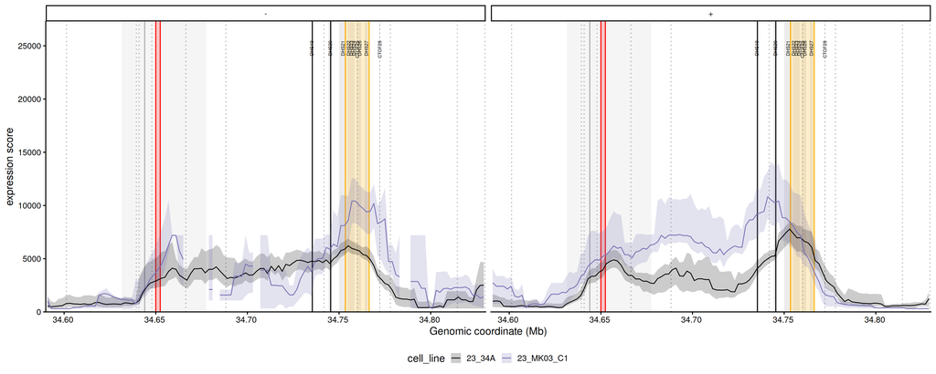

```r
expr_score_sum_per_cl_str %>%
  filter(cell_line %in% c("23_34A", "23_MK03_C1")) %>%
  ggplot(aes(x = mid_interval)) +
  facet_grid(. ~ strand) +

# -----------------------------------------------------------------------
# Ribeiro / Brosh proximal regulatory region
# -----------------------------------------------------------------------
geom_rect(data = Ribeiro_proximal_mm10,
          aes(xmin = start,
              xmax = end),
          ymin = -Inf,
          ymax = Inf,
          inherit.aes = FALSE,
          fill = "grey70",
          alpha = 0.12) +

# -----------------------------------------------------------------------
# Ribeiro / Brosh individual distal DHS / CTCF elements
# -----------------------------------------------------------------------
geom_rect(data = Ribeiro_distal_mm10,
          aes(xmin = start,
              xmax = end),
          ymin = -Inf,
          ymax = Inf,
          inherit.aes = FALSE,
          fill = "grey40",
          alpha = 0.12) +

# -----------------------------------------------------------------------
# Annotate SCR
# -----------------------------------------------------------------------
annotate("rect",
         xmin = start(enhancer),
         xmax = end(enhancer),
         ymin = -Inf,
         ymax = Inf,
         alpha = 0.2,
         fill = brown) +

  geom_vline(xintercept = c(start(enhancer),
                            end(enhancer)),
             col = brown) +

# -----------------------------------------------------------------------
# Annotate Sox2
# -----------------------------------------------------------------------
annotate("rect",
         xmin = start(Sox2_gene),
         xmax = end(Sox2_gene),
         ymin = -Inf,
         ymax = Inf,
         alpha = 0.2,
         fill = "red") +

  geom_vline(xintercept = c(start(Sox2_gene),
                            end(Sox2_gene)),
             col = "red") +

# -----------------------------------------------------------------------
# Launch pad
# -----------------------------------------------------------------------

geom_vline(xintercept = start(landingPad_23),
           col = "darkgrey") +

# -----------------------------------------------------------------------
# Our CTCF sites
# -----------------------------------------------------------------------

geom_vline(xintercept = start(CTCF_mm10.chr3_extra),
           col = "darkgrey",
           linetype = "dotted") +

# -----------------------------------------------------------------------
# 8-18kb mark
#-----------------------------------------------------------------------
geom_vline(
  xintercept = c(
    start(enhancer) - 18e3,
    start(enhancer) - 8e3),
  col = "black") +


# -----------------------------------------------------------------------
# Confidence interval
#-----------------------------------------------------------------------

geom_ribbon(
  aes(
    ymin = expr_score_window_lower_sel,
    ymax = expr_score_window_upper_sel,
    fill = cell_line),
  alpha = 0.2) +

# -----------------------------------------------------------------------
# Median expression score
# -----------------------------------------------------------------------
geom_line(
  aes(y = expr_score_window_median_sel,
      col = cell_line),
  linewidth = 0.6) +

  # Text annotation
  geom_text(
    data = Ribeiro_distal_mm10,
    aes(
      x = (start + end) / 2,
      y = 25500,
      label = label
    ),
    inherit.aes = FALSE,
    angle = 90,
    hjust = 1,
    size = 2.5
  ) +

# -----------------------------------------------------------------------
# Axes
# -----------------------------------------------------------------------

scale_x_continuous(
  breaks = scales::pretty_breaks(n = 6),
  labels = scales::unit_format(
    scale = 1E-6,
    accuracy = 0.01,
    unit = NULL),
  limits = prange_zoom_paper,
  expand = c(0, 0)) +

  scale_y_continuous(
    expand = expansion(mult = c(0, 0.05)),
    breaks = scales::pretty_breaks(n = 6),
    limits = c(0, 26e3)) +

  labs(
    x = "Genomic coordinate (Mb)",
    y = "expression score") +

  theme_classic(base_size = 16) +

  theme(legend.position = "bottom") +
  col_scale_MK_CL
```

# Hopping bias due to CBS inserts

- CBS inserts causes different hopping distributions
- use control sorted integrations for LP-116 kb

## reorder cell lines for plotting

```r
# add factor and levels for ordering
tib_filtered_curated_strict = tib_filtered_curated_strict %>%
  mutate(cell_line = factor(cell_line, levels = c("23_34A", "23_MK03_C1", "23_MK01_C5", "23_MK02_C2")))
```

## LP-116kb

```r
# count 1MB to the right and left of the LP, calculate fraction over total for each
tib_ctrl_fract_tot = tib_filtered_curated_strict %>% filter(population == "ctrl" & launch_pad_location == "-116 kb" & chr == "chr3" & hopped & start >= (start(landingPad_23)-1e6) & start <= start(landingPad_23)+1e6) %>%
  group_by(cell_line) %>% summarise(total_n = n())

# coordinate of the launch pad (numeric)
lp_coord <- start(landingPad_23)

# count upstream and downstream separately
tib_ctrl_fract_split <- tib_filtered_curated_strict %>%
  filter(population == "ctrl",
         launch_pad_location == "-116 kb",
         chr == "chr3",
         hopped,
         start >= (lp_coord - 1e6),
         start <= (lp_coord + 1e6)) %>%
  mutate(region = case_when(
    start < lp_coord ~ "upstream",
    start > lp_coord ~ "downstream",
    TRUE ~ "at_LP"
  )) %>%
  group_by(cell_line, region) %>%
  summarise(n = n(), .groups = "drop") %>%
  # join with total counts
  left_join(tib_ctrl_fract_tot, by = "cell_line") %>%
  mutate(frac = n / total_n)

tib_ctrl_fract_split
```

```
## # A tibble: 8 × 5
##   cell_line  region         n total_n  frac
##   <fct>      <chr>      <int>   <int> <dbl>
## 1 23_34A     downstream   677    1070 0.633
## 2 23_34A     upstream     393    1070 0.367
## 3 23_MK03_C1 downstream   479     618 0.775
## 4 23_MK03_C1 upstream     139     618 0.225
## 5 23_MK01_C5 downstream   207     251 0.825
## 6 23_MK01_C5 upstream      44     251 0.175
## 7 23_MK02_C2 downstream   185     466 0.397
## 8 23_MK02_C2 upstream     281     466 0.603
```

### Function to calculate p-value fisher test

```r
# Make a helper function: build a 2x2 table and run Fisher’s test
compare_to_control <- function(df, test_line, control_line = "23_34A") {
  sub <- df %>%
    filter(cell_line %in% c(control_line, test_line)) %>%
    select(cell_line, region, n) %>%
    pivot_wider(names_from = region, values_from = n)

  mat <- as.matrix(sub[, c("upstream", "downstream")])
  rownames(mat) <- sub$cell_line

  res <- fisher.test(mat)
  tibble(test_line = test_line,
         p_value = res$p.value,
         odds_ratio = res$estimate)
}

# Run for each MK line
results <- map_dfr(c("23_MK01_C5", "23_MK02_C2", "23_MK03_C1"),
                   ~compare_to_control(tib_ctrl_fract_split, .x))

results
```

```
## # A tibble: 3 × 3
##   test_line   p_value odds_ratio
##   <chr>         <dbl>      <dbl>
## 1 23_MK01_C5 1.79e- 9      2.73
## 2 23_MK02_C2 1.82e-17      0.382
## 3 23_MK03_C1 9.89e-10      2.00
```

**Conclusion:** MK01: odds ratio 2.73 → significantly more downstream integrations than control (p ≈ 1.8e-9). MK02: odds ratio 0.38 → significantly more upstream integrations than control (p ≈ 1.8e-17). MK03: odds ratio 2.0 → significantly more downstream integrations than control (p ≈ 9.9e-10). So compared to 23_34A, the MK lines show skewed distributions, but in opposite directions for MK02

### Plot results - Figure 6D

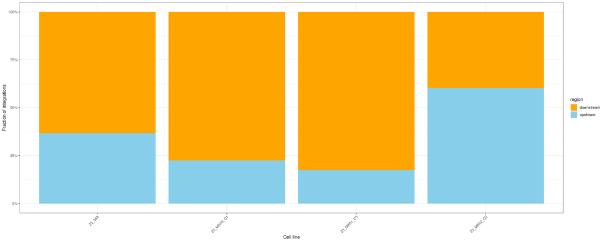

```r
ggplot(tib_ctrl_fract_split,
       aes(x = cell_line, y = frac, fill = region)) +
  geom_col(position = "fill") +
  scale_y_continuous(labels = scales::percent) +
  scale_fill_manual(values = c("upstream" = "skyblue", "downstream" = "orange")) +
  ylab("Fraction of integrations") +
  xlab("Cell line") +
  theme_bw() +
  theme(axis.text.x = element_text(angle = 45, hjust = 1))
```

[figure not shown]

```r
# Prep results for plotting (add significance stars)
results <- results %>%
  mutate(sig = case_when(
    p_value < 1e-10 ~ "***",
    p_value < 1e-5  ~ "**",
    p_value < 0.01  ~ "*",
    TRUE            ~ "ns"
  ))

# Fraction barplot
p <- ggplot(tib_ctrl_fract_split,
            aes(x = cell_line, y = frac, fill = region)) +
  geom_col(position = "fill") +
  scale_y_continuous(labels = scales::percent) +
  scale_fill_manual(values = c("upstream" = "skyblue", "downstream" = "orange")) +
  ylab("Fraction of integrations (±1 Mb)") +
  xlab("Cell line") +
  theme_bw() +
  theme(axis.text.x = element_text(angle = 45, hjust = 1))

# Add significance annotations comparing to 23_34A
p + geom_signif(
      comparisons = list(c("23_34A", "23_MK03_C1"),
                         c("23_34A", "23_MK01_C5"),
                         c("23_34A", "23_MK02_C2")),
      annotations = results$p_value ,
      y_position = c(1.05, 1.12, 1.19),  # adjust so stars are nicely spaced above bars
      tip_length = 0.01
    )
```

### Fraction of integrations in Sox2-SCR interval - Figure S5G

```r
tib_ctrl_fract_tot_LP116 = tib_filtered_curated_strict %>% filter(population == "ctrl" & launch_pad_location == "-116 kb" & chr == "chr3" & hopped & start >= (start(landingPad_23)-1e6) & start <= start(landingPad_23)+1e6) %>%
  group_by(cell_line) %>% summarise(total_n = n())

tib_ctrl_fract_Sox2_SCR_LP116 = tib_filtered_curated_strict %>%
  filter(population == "ctrl" & launch_pad_location == "-116 kb" & chr == "chr3" & hopped & start >= (end(Sox2_gene)) & start <= start(enhancer)) %>%
  group_by(cell_line) %>% summarise(Sox2_SCR_n = n()) %>% left_join(tib_ctrl_fract_tot_LP116) %>%
  mutate(fract_interval = Sox2_SCR_n/total_n)

kable(tib_ctrl_fract_Sox2_SCR_LP116)
```

| cell_line | Sox2_SCR_n | total_n | fract_interval |
| --- | --- | --- | --- |
| 23_34A | 132 | 1070 | 0.1233645 |
| 23_MK03_C1 | 93 | 618 | 0.1504854 |
| 23_MK01_C5 | 32 | 251 | 0.1274900 |
| 23_MK02_C2 | 59 | 466 | 0.1266094 |

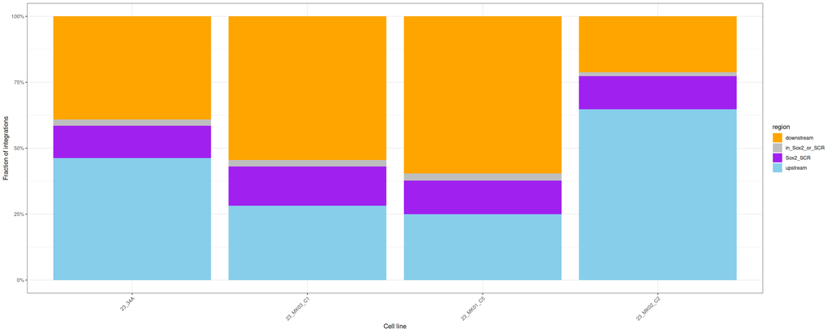

```r
# count 1MB to the left of Sox2 gene, than Sox2-SCR, 1Mb end of SCR, calculate fraction over total
tib_ctrl_fract_tot = tib_filtered_curated_strict %>% filter(population == "ctrl" & launch_pad_location == "-116 kb" & chr == "chr3" & hopped & start >= (start(Sox2_gene)-1e6) & start <= end(enhancer)+1e6) %>%
  group_by(cell_line) %>% summarise(total_n = n())

# coordinate of the launch pad (numeric)
Sox2_coord <- start(Sox2_gene)
SCR_coord <- end(enhancer)

# count upstream and downstream separately
tib_ctrl_fract_split <- tib_filtered_curated_strict %>%
  filter(population == "ctrl",
         launch_pad_location == "-116 kb",
         chr == "chr3",
         hopped,
         start >= (Sox2_coord - 1e6),
         start <= (SCR_coord + 1e6)) %>%
  mutate(region = case_when(
    start < Sox2_coord ~ "upstream",
    start > end(Sox2_gene) & start < start(enhancer) ~ "Sox2_SCR",
    start > SCR_coord ~ "downstream",
    TRUE ~ "in_Sox2_or_SCR"
  )) %>%
  group_by(cell_line, region) %>%
  summarise(n = n(), .groups = "drop") %>%
  # join with total counts
  left_join(tib_ctrl_fract_tot, by = "cell_line") %>%
  mutate(frac = n / total_n)

tib_ctrl_fract_split %>%
  ggplot(aes(x = cell_line, y = frac, fill = region)) +
  geom_bar(stat= "identity") +
  scale_y_continuous(labels = scales::percent) +
  scale_fill_manual(values = c("upstream" = "skyblue", "downstream" = "orange", "Sox2_SCR" = "purple", "in_Sox2_or_SCR" = "grey")) +
  ylab("Fraction of integrations") +
  xlab("Cell line") +
  theme_bw() +
  theme(axis.text.x = element_text(angle = 45, hjust = 1))
```

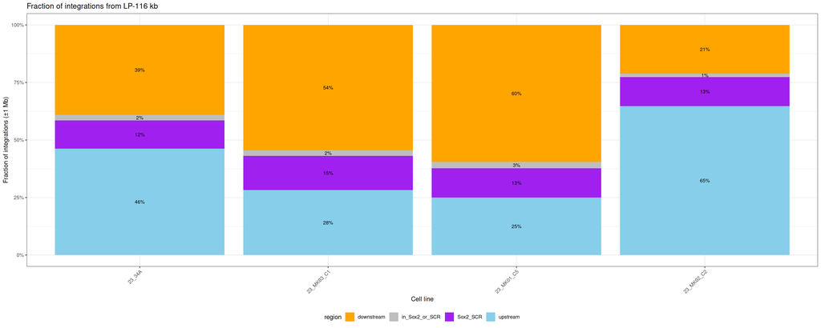

```r
# add % to plot
tib_ctrl_fract_split %>%
  ggplot(aes(x = cell_line, y = frac, fill = region)) +
  geom_bar(stat = "identity", position = "stack") +
  geom_text(aes(label = scales::percent(frac, accuracy = 1)),
            position = position_stack(vjust = 0.5),
            color = "black",
            size = 3) +
  scale_y_continuous(labels = scales::percent) +
  scale_fill_manual(values = c(
    "upstream" = "skyblue",
    "downstream" = "orange",
    "Sox2_SCR" = "purple",
    "in_Sox2_or_SCR" = "grey"
  )) +
  ylab("Fraction of integrations (±1 Mb)") +
  xlab("Cell line") +
  theme_bw() +
  theme(legend.position = "bottom") +
  ggtitle("Fraction of integrations from LP-116 kb") +
  theme(axis.text.x = element_text(angle = 45, hjust = 1))
```

## Plot beeswarms

### Sox2P - Figure S1B

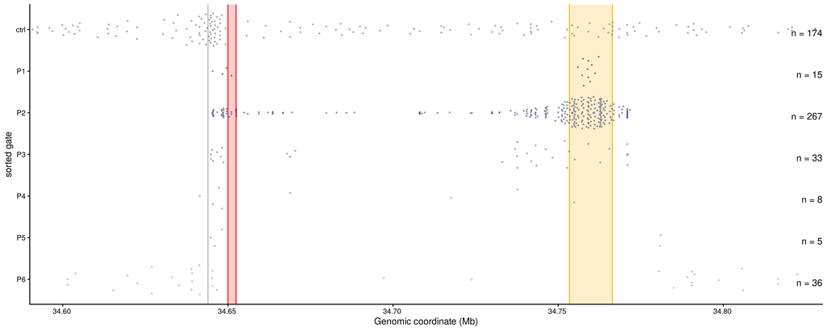

```r
all_exp = unique(tib_filtered_curated_strict$experiment)

#Rep 1
p23_34A_bs_rep1 =
plot_beeswarm_only(TIB = tib_filtered_curated_strict %>%
                   filter(hopped & chr == "chr3" & replicate == "rep1" & population != "P0") %>% droplevels(),
                   EXP = all_exp,
                   CL = "23_34A",
                   PLOT_ANNOT = T,
                   PLOT_CTCF = F,
                   P_RANGE = prange_zoom_paper,
                   POINT_SIZE = 1.5)
p23_34A_bs_rep1
```

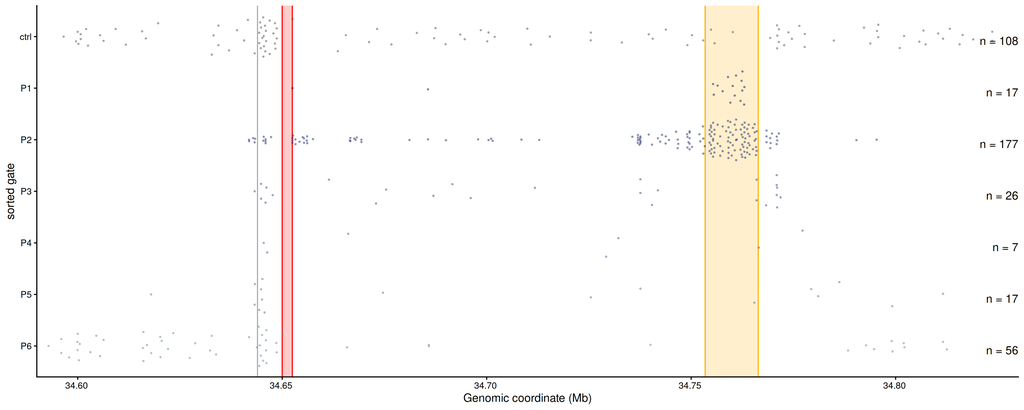

```r
#Rep 2
p23_34A_bs_rep2 =
plot_beeswarm_only(TIB = tib_filtered_curated_strict %>%
                   filter(hopped & chr == "chr3" & replicate == "rep2" & population != "P0") %>% droplevels(),
                   EXP = all_exp,
                   CL = "23_34A",
                   PLOT_ANNOT = T,
                   PLOT_CTCF = F,
                   P_RANGE = prange_zoom_paper,
                   POINT_SIZE = 1.5)
p23_34A_bs_rep2
```

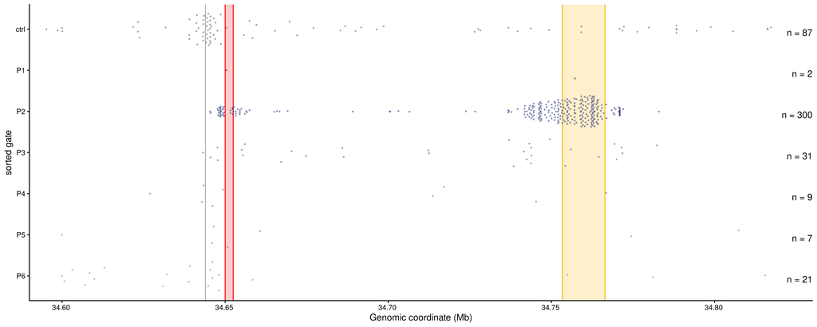

```r
#Rep 3
p23_34A_bs_rep3 =
plot_beeswarm_only(TIB = tib_filtered_curated_strict %>%
                   filter(hopped & chr == "chr3" & replicate == "rep3" & population != "P0") %>% droplevels(),
                   EXP = all_exp,
                   CL = "23_34A",
                   PLOT_ANNOT = T,
                   PLOT_CTCF = F,
                   P_RANGE = prange_zoom_paper,
                   POINT_SIZE = 1.5)
p23_34A_bs_rep3
```

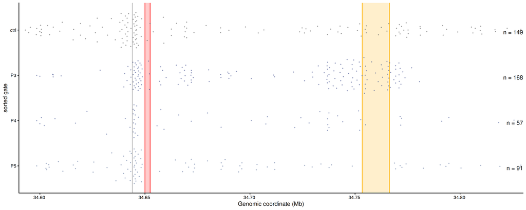

```r
#Rep 4
p23_34A_bs_rep4 =
plot_beeswarm_only(TIB = tib_filtered_curated_strict %>%
                   filter(hopped & chr == "chr3" & replicate == "rep4" & population != "P0") %>% droplevels(),
                   EXP = all_exp,
                   CL = "23_34A",
                   PLOT_ANNOT = T,
                   PLOT_CTCF = F,
                   P_RANGE = prange_zoom_paper,
                   POINT_SIZE = 1.5)
p23_34A_bs_rep4
```

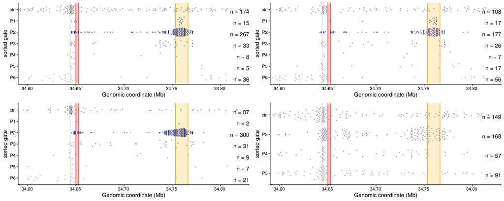

```r
plot_grid(p23_34A_bs_rep1, p23_34A_bs_rep2, p23_34A_bs_rep3, p23_34A_bs_rep4, ncol = 2)
```